# Health and Economic Consequences of Severe Weather Events in the U.S.A.

Christian A. Karanicolas

02/11/2020

# 1 Synopsis.

The analysis adresses the following questions:

- *Across the United States, which types of events are most harmful with respect to population health?*
- *Across the United States, which types of events have the greatest economic consequences?*

The [R language](https://www.r-project.org/about.html) was used both to obtain / clean / prepare the aforementioned database (*data processing* section) and to apply the exploration techniques for the analysis (*results* section). There’s a section at the end indicating the technical data regarding the software and hardware used to produce this report (*session info* section).

The main results that we found are that in the 60-year period recorded in the NOOA storm database across all the U.S.:

- The types of severe weather events related to *tornadoes, hurricanes and similars* are the most harmful types events with respect to population health in terms of deaths and injuries.
- The group of events related to *tides, tsunamies, floods and similars* has the greatest economic consequences in terms of property and crop damage considered jointly.
- Other specific results on damages considered separately (fatalities, injuries, property damage, crop damage) were also found.
- A final exploration of the data divided by decades raises the need for further analysis to determine the specific causes of trend changes observed from one decade to the next.

# 2 Data processing.

## 2.1 Downloading and reading the raw data in.

The storm database employed to perform this analysis is contained in the `repdata_data_StormData.csv.bze` compressed file downloaded from [this official web site](https://d396qusza40orc.cloudfront.net/repdata%2Fdata%2FStormData.csv.bz2)

The following code can be used to download the compressed file in the working directory, if it’s not already downloaded there.

```r
fileUrl <- "https://d396qusza40orc.cloudfront.net/repdata%2Fdata%2FStormData.csv.bz2"
destFile <- "repdata_data_StormData.csv.bz2"
if(!file.exists(destFile)) {
        download.file(fileUrl, destfile = destFile, method = "curl")
        dateDownloaded <- date()
}
```

The database belongs to the **U.S. National Oceanic and Atmospheric Administration (NOAA)**.

- It tracks the characteristics of mayor storms and weather events in the United States, including when and where they occur, as well as estimates of any fatalities, injuries and property damages.
- The events in it start in the year 1950 and end in November 2011.
- This National Weather [Storm Data Documentation](https://d396qusza40orc.cloudfront.net/repdata%2Fpeer2_doc%2Fpd01016005curr.pdf) explains how the variables or measures of interest were constructed/defined.

The following code reads in the dataset from the compressed file downloaded.

```r
library(R.utils)
library(data.table)

if(!exists("storm_db")) {
        storm_db <- fread(destFile)
}
```

Here we can see the first rows and columns of the data.

```r
library(dplyr)

storm_db <- as_tibble(storm_db)
storm_db
# A tibble: 902,297 × 37
   STATE__ BGN_DATE  BGN_TIME TIME_ZONE COUNTY COUNTYNAME STATE EVTYPE BGN_RANGE
     <dbl> <chr>     <chr>    <chr>      <dbl> <chr>      <chr> <chr>      <dbl>
 1       1 4/18/195… 0130     CST           97 MOBILE     AL    TORNA…         0
 2       1 4/18/195… 0145     CST            3 BALDWIN    AL    TORNA…         0
 3       1 2/20/195… 1600     CST           57 FAYETTE    AL    TORNA…         0
 4       1 6/8/1951… 0900     CST           89 MADISON    AL    TORNA…         0
 5       1 11/15/19… 1500     CST           43 CULLMAN    AL    TORNA…         0
 6       1 11/15/19… 2000     CST           77 LAUDERDALE AL    TORNA…         0
 7       1 11/16/19… 0100     CST            9 BLOUNT     AL    TORNA…         0
 8       1 1/22/195… 0900     CST          123 TALLAPOOSA AL    TORNA…         0
 9       1 2/13/195… 2000     CST          125 TUSCALOOSA AL    TORNA…         0
10       1 2/13/195… 2000     CST           57 FAYETTE    AL    TORNA…         0
# … with 902,287 more rows, and 28 more variables: BGN_AZI <chr>,
#   BGN_LOCATI <chr>, END_DATE <chr>, END_TIME <chr>, COUNTY_END <dbl>,
#   COUNTYENDN <lgl>, END_RANGE <dbl>, END_AZI <chr>, END_LOCATI <chr>,
#   LENGTH <dbl>, WIDTH <dbl>, F <int>, MAG <dbl>, FATALITIES <dbl>,
#   INJURIES <dbl>, PROPDMG <dbl>, PROPDMGEXP <chr>, CROPDMG <dbl>,
#   CROPDMGEXP <chr>, WFO <chr>, STATEOFFIC <chr>, ZONENAMES <chr>,
#   LATITUDE <dbl>, LONGITUDE <dbl>, LATITUDE_E <dbl>, LONGITUDE_ <dbl>, …
```

- The output also lists *at the bottom* all the variables in the dataset.

## 2.2 Data preparation.

### 2.2.1 Variables of interest.

In order to perform the analysis we are interested in, we don’t need all of the 37 variables in the dataset but only a subset of them.

In particular, we’ll focus on the information contained in the following variables:

- `EVTYPE`: name of the type of extreme weather event.
- `STATE`: two-letter State abbreviations, identifying the State where the event occurred.
- `BGN_DATE`: beginning date of the event (the dataset contains other time related variables, like the precise beginning time and the ending date and time of the event but, for our purposes, we take the beginning date just to keep track of the event’s ocurrence in time).
- `FATALITIES`: number of fatalities.
- `INJURIES`: number of injuries.
- `PROPDMG`: property damage estimates as actual dollar amounts, rounded to three significant digits.
- `PROPDMGEXP`: alphabetical character signifying the magnitude of the property damage number (“K” for thousands, “M” for millions, “B” for billions).
- `CROPDMG`: crop damage estimates as actual dollar amounts.
- `CROPDMGEXP`: alphabetical character signifying the magnitude of the crop damage number (“K” for thousands, “M” for millions, “B” for billions).

### 2.2.2 Selecting and formatting variables of interest.

The following code selects our variables of interest and gives them a convinient format for the analysis.

```r
library(dplyr)

storm_tidy <- storm_db %>%
        select(EVTYPE, STATE, BGN_DATE, FATALITIES, INJURIES,
               PROPDMG, PROPDMGEXP, CROPDMG, CROPDMGEXP) %>%
        mutate(EVTYPE = as.factor(EVTYPE),
               STATE = as.factor(STATE),
               BGN_DATE = as.Date(BGN_DATE, format = "%m/%d/%Y %H:%M:%S"),
               PROPDMGEXP = as.factor(PROPDMGEXP),
               CROPDMGEXP = as.factor(CROPDMGEXP))
```

Here’s the result.

```r
storm_tidy
# A tibble: 902,297 × 9
   EVTYPE  STATE BGN_DATE   FATALITIES INJURIES PROPDMG PROPDMGEXP CROPDMG
   <fct>   <fct> <date>          <dbl>    <dbl>   <dbl> <fct>        <dbl>
 1 TORNADO AL    1950-04-18          0       15    25   K                0
 2 TORNADO AL    1950-04-18          0        0     2.5 K                0
 3 TORNADO AL    1951-02-20          0        2    25   K                0
 4 TORNADO AL    1951-06-08          0        2     2.5 K                0
 5 TORNADO AL    1951-11-15          0        2     2.5 K                0
 6 TORNADO AL    1951-11-15          0        6     2.5 K                0
 7 TORNADO AL    1951-11-16          0        1     2.5 K                0
 8 TORNADO AL    1952-01-22          0        0     2.5 K                0
 9 TORNADO AL    1952-02-13          1       14    25   K                0
10 TORNADO AL    1952-02-13          0        0    25   K                0
# … with 902,287 more rows, and 1 more variable: CROPDMGEXP <fct>
```

### 2.2.3 Checking the global content of the variables.

Let’s look at the following summaries of the content of these variables.

```r
summary(storm_tidy)
               EVTYPE           STATE           BGN_DATE
 HAIL             :288661   TX     : 83728   Min.   :1950-01-03
 TSTM WIND        :219940   KS     : 53440   1st Qu.:1995-04-20
 THUNDERSTORM WIND: 82563   OK     : 46802   Median :2002-03-18
 TORNADO          : 60652   MO     : 35648   Mean   :1998-12-27
 FLASH FLOOD      : 54277   IA     : 31069   3rd Qu.:2007-07-28
 FLOOD            : 25326   NE     : 30271   Max.   :2011-11-30
 (Other)          :170878   (Other):621339
   FATALITIES          INJURIES            PROPDMG          PROPDMGEXP
 Min.   :  0.0000   Min.   :   0.0000   Min.   :   0.00          :465934
 1st Qu.:  0.0000   1st Qu.:   0.0000   1st Qu.:   0.00   K      :424665
 Median :  0.0000   Median :   0.0000   Median :   0.00   M      : 11330
 Mean   :  0.0168   Mean   :   0.1557   Mean   :  12.06   0      :   216
 3rd Qu.:  0.0000   3rd Qu.:   0.0000   3rd Qu.:   0.50   B      :    40
 Max.   :583.0000   Max.   :1700.0000   Max.   :5000.00   5      :    28
                                                          (Other):    84
    CROPDMG          CROPDMGEXP
 Min.   :  0.000          :618413
 1st Qu.:  0.000   K      :281832
 Median :  0.000   M      :  1994
 Mean   :  1.527   k      :    21
 3rd Qu.:  0.000   0      :    19
 Max.   :990.000   B      :     9
                   (Other):     9
```

Among other things, this output shows us that:

- The variables that indicate the magnitud of the property damage (`PROPDMGEXP`) and crop damage (`CROPDMGEXP`), on the one hand, contain mostly blank spaces and, on the other, use several symbols (in addition to simply “K”, “M” and “B”) to encode the magnitudes.
  - In the next section we’ll specifically consider this aspect, in order to properly calculate the damage’s magnitudes.
- We can also see here, for instance, the most frequent type of events (in `EVTYPE` we find that `HAIL` is the most frequent type of event with 288661 occurrences) and the States with the highest numbers of events (in `STATE`, `TX` leads the frequency ranking with 83728 occurrences).
  - Bellow, we’ll also focus on the type of events variable (`EVTYPE`), how is it composed and organized, because this is the variable that we are going to use to group the damage calculations.

### 2.2.4 Calculating the magnitude of the property and crop damage.

Let’s see in detail what symbols do the `PROPDMGEXP` and `CROPDMGEXP` use.

```r
levels(storm_tidy$PROPDMGEXP)
 [1] ""  "-" "?" "+" "0" "1" "2" "3" "4" "5" "6" "7" "8" "B" "h" "H" "K" "m" "M"

levels(storm_tidy$CROPDMGEXP)
[1] ""  "?" "0" "2" "B" "k" "K" "m" "M"
```

From the summaries we did before, we know that:

- the symbols `-`, `?` and `+` contained in `PROPDMGEXP` are, at most, 84 (see “Other” category);
- the symbol `?` contained in `CROPDMGEXP` occurs, at most, 9 times (see “Other” category).

Although it is true that the proportion of those cases with respect to the total number of events is negligible (less than 0,01% in the first case and less than 0,001% percent in the second), let us verify however that an event with extraordinary harmful consecuences is not included there.

To do so, let’s see what the events these symbols refer to are about.

```r
library(dplyr)

storm_tidy %>%
        filter(PROPDMGEXP %in% c("-", "+", "?")) %>%
        select(-c(STATE, BGN_DATE))
# A tibble: 14 × 7
   EVTYPE              FATALITIES INJURIES PROPDMG PROPDMGEXP CROPDMG CROPDMGEXP
   <fct>                    <dbl>    <dbl>   <dbl> <fct>        <dbl> <fct>
 1 BREAKUP FLOODING             0        0      20 +                0 ""
 2 HIGH WIND                    0        0      20 +                0 ""
 3 FLOODING/HEAVY RAIN          0        0       2 +                0 ""
 4 THUNDERSTORM WINDS           0        0       0 ?                0 ""
 5 HIGH WINDS                   0        0      15 +                0 ""
 6 TORNADO                      0        0      60 +                0 ""
 7 FLASH FLOOD                  0        0       0 ?                0 ""
 8 FLASH FLOOD                  0        0       0 ?                0 ""
 9 HIGH WIND                    2        0      15 -                0 ""
10 THUNDERSTORM WIND            0        0       0 ?                0 ""
11 HAIL                         0        0       0 ?                0 ""
12 HAIL                         0        0       0 ?                0 ""
13 HAIL                         0        0       0 ?                0 ""
14 THUNDERSTORM WINDS           0        0       0 ?                0 ""

storm_tidy %>%
        filter(CROPDMGEXP == "?") %>%
        select(-c(STATE, BGN_DATE))
# A tibble: 7 × 7
  EVTYPE             FATALITIES INJURIES PROPDMG PROPDMGEXP CROPDMG CROPDMGEXP
  <fct>                   <dbl>    <dbl>   <dbl> <fct>        <dbl> <fct>
1 FLASH FLOOD WINDS           0        0    0.41 ""               0 ?
2 THUNDERSTORM WINDS          0        0    0.5  "K"              0 ?
3 THUNDERSTORM WINDS          0        0    0.5  "K"              0 ?
4 THUNDERSTORM WINDS          0        0    0    ""               0 ?
5 FLOOD/FLASH FLOOD           0        0  400    "K"              0 ?
6 FLOOD/FLASH FLOOD           0        0    0.5  "M"              0 ?
7 THUNDERSTORM WINDS          0        0   80    "K"              0 ?
```

As we can see:

- there are a couple of `FLOOD` related events with about a half a million dollars of property damage and a `HIGH WIND` event with two fatalities;
- all the events characterized with the `?` symbol in `PROPDMGEXT` have zero property damage (and no other consecuencies);
- all the events characterized with the `?` symbol in `CROPDMGEXT` have zero crop damage.

Instead of discarding these cases, we are going to replace both the symbol `?` and the symbols `-` and `+`, with a “blank space” (technically called *null string* and denoted as `""`).

This is the code that computes that task:

```r
library(dplyr)

storm_tidy <- storm_tidy %>%
        mutate(PROPDMGEXP = ifelse(PROPDMGEXP %in% c("-", "+", "?"), "", as.character(PROPDMGEXP)),
               PROPDMGEXP = as.factor(PROPDMGEXP),
               CROPDMGEXP = ifelse(CROPDMGEXP == "?", "", as.character(CROPDMGEXP)),
               CROPDMGEXP = as.factor(CROPDMGEXP))
```

Now, `PROPDMGEXP` and `CROPDMGEXP` contain these symbols:

```r
levels(storm_tidy$PROPDMGEXP)
 [1] ""  "0" "1" "2" "3" "4" "5" "6" "7" "8" "B" "h" "H" "K" "m" "M"

levels(storm_tidy$CROPDMGEXP)
[1] ""  "0" "2" "B" "k" "K" "m" "M"
```

This solution wont affect the conclusions of our analysis, because of the negligible proportion of cases involved.

So, we can move on and calculate the amount of property and crop damage using the exponents specified in the `PROPDMGEXP` and `CROPDMGEXP` variables. The following table shows the association between the exponents coded in those variables and the multiplier that we’ll use to perform the calculations.

| Symbol | Exponent | Multiplier |
| --- | --- | --- |
| “” | e0 | 1*e0 |
| “0” | e0 | 1*e0 |
| “1” | e1 | 1*e1 |
| “2” | e2 | 1*e2 |
| “h” | e2 | 1*e2 |
| “H” | e2 | 1*e2 |
| “3” | e3 | 1*e3 |
| “k” | e3 | 1*e3 |
| “K” | e3 | 1*e3 |
| “4” | e4 | 1*e4 |
| “5” | e5 | 1*e5 |
| “6” | e6 | 1*e6 |
| “m” | e6 | 1*e6 |
| “M” | e6 | 1*e6 |
| “7” | e7 | 1*e7 |
| “8” | e8 | 1*e8 |
| “B” | e9 | 1*e9 |

- Notice that we associated **“blank spaces” (`""`)** to a magnitud with **exponent `0` (`e0`)**

The following code creates two new variables, `PROPDMGTOT` and `CROPDMGTOT`, where the results of the amount of property and crop damage calculation are respectively stored.

```r
library(dplyr)

## Getting the symbols used in PROPDMGEXP and CROPDMGEXP
symbols <- storm_tidy %>%
        select(PROPDMGEXP, CROPDMGEXP) %>%
        t %>% c %>%
        unique %>% sort
symbols
 [1] ""  "0" "1" "2" "3" "4" "5" "6" "7" "8" "B" "h" "H" "k" "K" "m" "M"

## Constructing the multiplier vector
multiplier <- numeric(length(symbols))
for(i in seq_along(symbols)) {
        if(symbols[i] %in% c("", "0")) multiplier[i] <- 1e0
        if(symbols[i] == "1") multiplier[i] <- 1e1
        if(symbols[i] %in% c("2", "h", "H")) multiplier[i] <- 1e2
        if(symbols[i] %in% c("3", "k", "K")) multiplier[i] <- 1e3
        if(symbols[i] == "4") multiplier[i] <- 1e4
        if(symbols[i] == "5") multiplier[i] <- 1e5
        if(symbols[i] %in% c("6", "m", "M")) multiplier[i] <- 1e6
        if(symbols[i] == "7") multiplier[i] <- 1e7
        if(symbols[i] == "8") multiplier[i] <- 1e8
        if(symbols[i] == "B") multiplier[i] <- 1e9
}
names(multiplier) <- symbols
multiplier
          0     1     2     3     4     5     6     7     8     B     h     H
1e+00 1e+00 1e+01 1e+02 1e+03 1e+04 1e+05 1e+06 1e+07 1e+08 1e+09 1e+02 1e+02
    k     K     m     M
1e+03 1e+03 1e+06 1e+06

## Creating two new variables (PROPDMGTOT and CROPDMGTOT) with the results of the
## amount of property and crop damage calculation
storm_tidy <- storm_tidy %>%
        mutate(PROPDMGTOT = PROPDMG * multiplier[PROPDMGEXP],
               CROPDMGTOT = CROPDMG * multiplier[CROPDMGEXP])
```

Here we can see the new created variables containing the total amount, in dollars, of property damage (`PROPDMGTOT`) and crop damage (`CROPDMGTOT`).

```r
library(dplyr)

storm_tidy %>%
        select(PROPDMG, PROPDMGEXP, PROPDMGTOT,
               CROPDMG, CROPDMGEXP, CROPDMGTOT)
# A tibble: 902,297 × 6
   PROPDMG PROPDMGEXP PROPDMGTOT CROPDMG CROPDMGEXP CROPDMGTOT
     <dbl> <fct>           <dbl>   <dbl> <fct>           <dbl>
 1    25   K               25000       0 ""                  0
 2     2.5 K                2500       0 ""                  0
 3    25   K               25000       0 ""                  0
 4     2.5 K                2500       0 ""                  0
 5     2.5 K                2500       0 ""                  0
 6     2.5 K                2500       0 ""                  0
 7     2.5 K                2500       0 ""                  0
 8     2.5 K                2500       0 ""                  0
 9    25   K               25000       0 ""                  0
10    25   K               25000       0 ""                  0
# … with 902,287 more rows
```

So we can remove form our dataset the `PROPDMG`, `PROPDMGEXP`, `CROPDMG` and `CROPDMGEXP` variables.

```r
library(dplyr)

storm_tidy <- storm_tidy %>%
        select(-c(PROPDMG, PROPDMGEXP, CROPDMG, CROPDMGEXP))
```

Therefore, this is how our dataset looks like so far.

```r
storm_tidy
# A tibble: 902,297 × 7
   EVTYPE  STATE BGN_DATE   FATALITIES INJURIES PROPDMGTOT CROPDMGTOT
   <fct>   <fct> <date>          <dbl>    <dbl>      <dbl>      <dbl>
 1 TORNADO AL    1950-04-18          0       15      25000          0
 2 TORNADO AL    1950-04-18          0        0       2500          0
 3 TORNADO AL    1951-02-20          0        2      25000          0
 4 TORNADO AL    1951-06-08          0        2       2500          0
 5 TORNADO AL    1951-11-15          0        2       2500          0
 6 TORNADO AL    1951-11-15          0        6       2500          0
 7 TORNADO AL    1951-11-16          0        1       2500          0
 8 TORNADO AL    1952-01-22          0        0       2500          0
 9 TORNADO AL    1952-02-13          1       14      25000          0
10 TORNADO AL    1952-02-13          0        0      25000          0
# … with 902,287 more rows
```

### 2.2.5 Organizing the types of events.

As we anticipated, let us focus now on the `EVTYPE` variable.

We’ve already made a summary of it and saw the most frequent types of events. But we want to know precisely how many types of events are there.

This code gives us that information:

```r
levels(storm_tidy$EVTYPE)
  [1] "   HIGH SURF ADVISORY"          " COASTAL FLOOD"
  [3] " FLASH FLOOD"                   " LIGHTNING"
  [5] " TSTM WIND"                     " TSTM WIND (G45)"
  [7] " WATERSPOUT"                    " WIND"
  [9] "?"                              "ABNORMAL WARMTH"
 [11] "ABNORMALLY DRY"                 "ABNORMALLY WET"
 [13] "ACCUMULATED SNOWFALL"           "AGRICULTURAL FREEZE"
 [15] "APACHE COUNTY"                  "ASTRONOMICAL HIGH TIDE"
 [17] "ASTRONOMICAL LOW TIDE"          "AVALANCE"
 [19] "AVALANCHE"                      "BEACH EROSIN"
 [21] "Beach Erosion"                  "BEACH EROSION"
 [23] "BEACH EROSION/COASTAL FLOOD"    "BEACH FLOOD"
 [25] "BELOW NORMAL PRECIPITATION"     "BITTER WIND CHILL"
 [27] "BITTER WIND CHILL TEMPERATURES" "Black Ice"
 [29] "BLACK ICE"                      "BLIZZARD"
 [31] "BLIZZARD AND EXTREME WIND CHIL" "BLIZZARD AND HEAVY SNOW"
 [33] "Blizzard Summary"               "BLIZZARD WEATHER"
 [35] "BLIZZARD/FREEZING RAIN"         "BLIZZARD/HEAVY SNOW"
 [37] "BLIZZARD/HIGH WIND"             "BLIZZARD/WINTER STORM"
 [39] "BLOW-OUT TIDE"                  "BLOW-OUT TIDES"
 [41] "BLOWING DUST"                   "blowing snow"
 [43] "Blowing Snow"                   "BLOWING SNOW"
 [45] "BLOWING SNOW & EXTREME WIND CH" "BLOWING SNOW- EXTREME WIND CHI"
 [47] "BLOWING SNOW/EXTREME WIND CHIL" "BREAKUP FLOODING"
 [49] "BRUSH FIRE"                     "BRUSH FIRES"
 [51] "COASTAL  FLOODING/EROSION"      "COASTAL EROSION"
 [53] "Coastal Flood"                  "COASTAL FLOOD"
 [55] "coastal flooding"               "Coastal Flooding"
 [57] "COASTAL FLOODING"               "COASTAL FLOODING/EROSION"
 [59] "Coastal Storm"                  "COASTAL STORM"
 [61] "COASTAL SURGE"                  "COASTAL/TIDAL FLOOD"
 [63] "COASTALFLOOD"                   "COASTALSTORM"
 [65] "Cold"                           "COLD"
 [67] "COLD AIR FUNNEL"                "COLD AIR FUNNELS"
 [69] "COLD AIR TORNADO"               "Cold and Frost"
 [71] "COLD AND FROST"                 "COLD AND SNOW"
 [73] "COLD AND WET CONDITIONS"        "Cold Temperature"
 [75] "COLD TEMPERATURES"              "COLD WAVE"
 [77] "COLD WEATHER"                   "COLD WIND CHILL TEMPERATURES"
 [79] "COLD/WIND CHILL"                "COLD/WINDS"
 [81] "COOL AND WET"                   "COOL SPELL"
 [83] "CSTL FLOODING/EROSION"          "DAM BREAK"
 [85] "DAM FAILURE"                    "Damaging Freeze"
 [87] "DAMAGING FREEZE"                "DEEP HAIL"
 [89] "DENSE FOG"                      "DENSE SMOKE"
 [91] "DOWNBURST"                      "DOWNBURST WINDS"
 [93] "DRIEST MONTH"                   "Drifting Snow"
 [95] "DROUGHT"                        "DROUGHT/EXCESSIVE HEAT"
 [97] "DROWNING"                       "DRY"
 [99] "DRY CONDITIONS"                 "DRY HOT WEATHER"
[101] "DRY MICROBURST"                 "DRY MICROBURST 50"
[103] "DRY MICROBURST 53"              "DRY MICROBURST 58"
[105] "DRY MICROBURST 61"              "DRY MICROBURST 84"
[107] "DRY MICROBURST WINDS"           "DRY MIRCOBURST WINDS"
[109] "DRY PATTERN"                    "DRY SPELL"
[111] "DRY WEATHER"                    "DRYNESS"
[113] "DUST DEVEL"                     "Dust Devil"
[115] "DUST DEVIL"                     "DUST DEVIL WATERSPOUT"
[117] "DUST STORM"                     "DUST STORM/HIGH WINDS"
[119] "DUSTSTORM"                      "EARLY FREEZE"
[121] "Early Frost"                    "EARLY FROST"
[123] "EARLY RAIN"                     "EARLY SNOW"
[125] "Early snowfall"                 "EARLY SNOWFALL"
[127] "Erosion/Cstl Flood"             "EXCESSIVE"
[129] "Excessive Cold"                 "EXCESSIVE HEAT"
[131] "EXCESSIVE HEAT/DROUGHT"         "EXCESSIVE PRECIPITATION"
[133] "EXCESSIVE RAIN"                 "EXCESSIVE RAINFALL"
[135] "EXCESSIVE SNOW"                 "EXCESSIVE WETNESS"
[137] "EXCESSIVELY DRY"                "Extended Cold"
[139] "Extreme Cold"                   "EXTREME COLD"
[141] "EXTREME COLD/WIND CHILL"        "EXTREME HEAT"
[143] "EXTREME WIND CHILL"             "EXTREME WIND CHILL/BLOWING SNO"
[145] "EXTREME WIND CHILLS"            "EXTREME WINDCHILL"
[147] "EXTREME WINDCHILL TEMPERATURES" "EXTREME/RECORD COLD"
[149] "EXTREMELY WET"                  "FALLING SNOW/ICE"
[151] "FIRST FROST"                    "FIRST SNOW"
[153] "FLASH FLOOD"                    "FLASH FLOOD - HEAVY RAIN"
[155] "FLASH FLOOD FROM ICE JAMS"      "FLASH FLOOD LANDSLIDES"
[157] "FLASH FLOOD WINDS"              "FLASH FLOOD/"
[159] "FLASH FLOOD/ FLOOD"             "FLASH FLOOD/ STREET"
[161] "FLASH FLOOD/FLOOD"              "FLASH FLOOD/HEAVY RAIN"
[163] "FLASH FLOOD/LANDSLIDE"          "FLASH FLOODING"
[165] "FLASH FLOODING/FLOOD"           "FLASH FLOODING/THUNDERSTORM WI"
[167] "FLASH FLOODS"                   "FLASH FLOOODING"
[169] "Flood"                          "FLOOD"
[171] "FLOOD & HEAVY RAIN"             "FLOOD FLASH"
[173] "FLOOD FLOOD/FLASH"              "FLOOD WATCH/"
[175] "FLOOD/FLASH"                    "Flood/Flash Flood"
[177] "FLOOD/FLASH FLOOD"              "FLOOD/FLASH FLOODING"
[179] "FLOOD/FLASH/FLOOD"              "FLOOD/FLASHFLOOD"
[181] "FLOOD/RAIN/WIND"                "FLOOD/RAIN/WINDS"
[183] "FLOOD/RIVER FLOOD"              "Flood/Strong Wind"
[185] "FLOODING"                       "FLOODING/HEAVY RAIN"
[187] "FLOODS"                         "FOG"
[189] "FOG AND COLD TEMPERATURES"      "FOREST FIRES"
[191] "Freeze"                         "FREEZE"
[193] "Freezing drizzle"               "Freezing Drizzle"
[195] "FREEZING DRIZZLE"               "FREEZING DRIZZLE AND FREEZING"
[197] "Freezing Fog"                   "FREEZING FOG"
[199] "Freezing rain"                  "Freezing Rain"
[201] "FREEZING RAIN"                  "FREEZING RAIN AND SLEET"
[203] "FREEZING RAIN AND SNOW"         "FREEZING RAIN SLEET AND"
[205] "FREEZING RAIN SLEET AND LIGHT"  "FREEZING RAIN/SLEET"
[207] "FREEZING RAIN/SNOW"             "Freezing Spray"
[209] "Frost"                          "FROST"
[211] "Frost/Freeze"                   "FROST/FREEZE"
[213] "FROST\\FREEZE"                  "FUNNEL"
[215] "Funnel Cloud"                   "FUNNEL CLOUD"
[217] "FUNNEL CLOUD."                  "FUNNEL CLOUD/HAIL"
[219] "FUNNEL CLOUDS"                  "FUNNELS"
[221] "Glaze"                          "GLAZE"
[223] "GLAZE ICE"                      "GLAZE/ICE STORM"
[225] "gradient wind"                  "Gradient wind"
[227] "GRADIENT WIND"                  "GRADIENT WINDS"
[229] "GRASS FIRES"                    "GROUND BLIZZARD"
[231] "GUSTNADO"                       "GUSTNADO AND"
[233] "GUSTY LAKE WIND"                "GUSTY THUNDERSTORM WIND"
[235] "GUSTY THUNDERSTORM WINDS"       "Gusty Wind"
[237] "GUSTY WIND"                     "GUSTY WIND/HAIL"
[239] "GUSTY WIND/HVY RAIN"            "Gusty wind/rain"
[241] "Gusty winds"                    "Gusty Winds"
[243] "GUSTY WINDS"                    "HAIL"
[245] "HAIL 0.75"                      "HAIL 0.88"
[247] "HAIL 075"                       "HAIL 088"
[249] "HAIL 1.00"                      "HAIL 1.75"
[251] "HAIL 1.75)"                     "HAIL 100"
[253] "HAIL 125"                       "HAIL 150"
[255] "HAIL 175"                       "HAIL 200"
[257] "HAIL 225"                       "HAIL 275"
[259] "HAIL 450"                       "HAIL 75"
[261] "HAIL 80"                        "HAIL 88"
[263] "HAIL ALOFT"                     "HAIL DAMAGE"
[265] "HAIL FLOODING"                  "HAIL STORM"
[267] "Hail(0.75)"                     "HAIL/ICY ROADS"
[269] "HAIL/WIND"                      "HAIL/WINDS"
[271] "HAILSTORM"                      "HAILSTORMS"
[273] "HARD FREEZE"                    "HAZARDOUS SURF"
[275] "HEAT"                           "HEAT DROUGHT"
[277] "Heat Wave"                      "HEAT WAVE"
[279] "HEAT WAVE DROUGHT"              "HEAT WAVES"
[281] "HEAT/DROUGHT"                   "Heatburst"
[283] "HEAVY LAKE SNOW"                "HEAVY MIX"
[285] "HEAVY PRECIPATATION"            "Heavy Precipitation"
[287] "HEAVY PRECIPITATION"            "Heavy rain"
[289] "Heavy Rain"                     "HEAVY RAIN"
[291] "HEAVY RAIN AND FLOOD"           "Heavy Rain and Wind"
[293] "HEAVY RAIN EFFECTS"             "HEAVY RAIN; URBAN FLOOD WINDS;"
[295] "HEAVY RAIN/FLOODING"            "Heavy Rain/High Surf"
[297] "HEAVY RAIN/LIGHTNING"           "HEAVY RAIN/MUDSLIDES/FLOOD"
[299] "HEAVY RAIN/SEVERE WEATHER"      "HEAVY RAIN/SMALL STREAM URBAN"
[301] "HEAVY RAIN/SNOW"                "HEAVY RAIN/URBAN FLOOD"
[303] "HEAVY RAIN/WIND"                "HEAVY RAINFALL"
[305] "HEAVY RAINS"                    "HEAVY RAINS/FLOODING"
[307] "HEAVY SEAS"                     "HEAVY SHOWER"
[309] "HEAVY SHOWERS"                  "HEAVY SNOW"
[311] "HEAVY SNOW   FREEZING RAIN"     "HEAVY SNOW & ICE"
[313] "HEAVY SNOW AND"                 "HEAVY SNOW AND HIGH WINDS"
[315] "HEAVY SNOW AND ICE"             "HEAVY SNOW AND ICE STORM"
[317] "HEAVY SNOW AND STRONG WINDS"    "HEAVY SNOW ANDBLOWING SNOW"
[319] "Heavy snow shower"              "HEAVY SNOW SQUALLS"
[321] "HEAVY SNOW-SQUALLS"             "HEAVY SNOW/BLIZZARD"
[323] "HEAVY SNOW/BLIZZARD/AVALANCHE"  "HEAVY SNOW/BLOWING SNOW"
[325] "HEAVY SNOW/FREEZING RAIN"       "HEAVY SNOW/HIGH"
[327] "HEAVY SNOW/HIGH WIND"           "HEAVY SNOW/HIGH WINDS"
[329] "HEAVY SNOW/HIGH WINDS & FLOOD"  "HEAVY SNOW/HIGH WINDS/FREEZING"
[331] "HEAVY SNOW/ICE"                 "HEAVY SNOW/ICE STORM"
[333] "HEAVY SNOW/SLEET"               "HEAVY SNOW/SQUALLS"
[335] "HEAVY SNOW/WIND"                "HEAVY SNOW/WINTER STORM"
[337] "HEAVY SNOWPACK"                 "Heavy Surf"
[339] "HEAVY SURF"                     "Heavy surf and wind"
[341] "HEAVY SURF COASTAL FLOODING"    "HEAVY SURF/HIGH SURF"
[343] "HEAVY SWELLS"                   "HEAVY WET SNOW"
[345] "HIGH"                           "HIGH  SWELLS"
[347] "HIGH  WINDS"                    "HIGH SEAS"
[349] "High Surf"                      "HIGH SURF"
[351] "HIGH SURF ADVISORIES"           "HIGH SURF ADVISORY"
[353] "HIGH SWELLS"                    "HIGH TEMPERATURE RECORD"
[355] "HIGH TIDES"                     "HIGH WATER"
[357] "HIGH WAVES"                     "High Wind"
[359] "HIGH WIND"                      "HIGH WIND (G40)"
[361] "HIGH WIND 48"                   "HIGH WIND 63"
[363] "HIGH WIND 70"                   "HIGH WIND AND HEAVY SNOW"
[365] "HIGH WIND AND HIGH TIDES"       "HIGH WIND AND SEAS"
[367] "HIGH WIND DAMAGE"               "HIGH WIND/ BLIZZARD"
[369] "HIGH WIND/BLIZZARD"             "HIGH WIND/BLIZZARD/FREEZING RA"
[371] "HIGH WIND/HEAVY SNOW"           "HIGH WIND/LOW WIND CHILL"
[373] "HIGH WIND/SEAS"                 "HIGH WIND/WIND CHILL"
[375] "HIGH WIND/WIND CHILL/BLIZZARD"  "HIGH WINDS"
[377] "HIGH WINDS 55"                  "HIGH WINDS 57"
[379] "HIGH WINDS 58"                  "HIGH WINDS 63"
[381] "HIGH WINDS 66"                  "HIGH WINDS 67"
[383] "HIGH WINDS 73"                  "HIGH WINDS 76"
[385] "HIGH WINDS 80"                  "HIGH WINDS 82"
[387] "HIGH WINDS AND WIND CHILL"      "HIGH WINDS DUST STORM"
[389] "HIGH WINDS HEAVY RAINS"         "HIGH WINDS/"
[391] "HIGH WINDS/COASTAL FLOOD"       "HIGH WINDS/COLD"
[393] "HIGH WINDS/FLOODING"            "HIGH WINDS/HEAVY RAIN"
[395] "HIGH WINDS/SNOW"                "HIGHWAY FLOODING"
[397] "Hot and Dry"                    "HOT PATTERN"
[399] "HOT SPELL"                      "HOT WEATHER"
[401] "HOT/DRY PATTERN"                "HURRICANE"
[403] "Hurricane Edouard"              "HURRICANE EMILY"
[405] "HURRICANE ERIN"                 "HURRICANE FELIX"
[407] "HURRICANE GORDON"               "HURRICANE OPAL"
[409] "HURRICANE OPAL/HIGH WINDS"      "HURRICANE-GENERATED SWELLS"
[411] "HURRICANE/TYPHOON"              "HVY RAIN"
[413] "HYPERTHERMIA/EXPOSURE"          "HYPOTHERMIA"
[415] "Hypothermia/Exposure"           "HYPOTHERMIA/EXPOSURE"
[417] "ICE"                            "ICE AND SNOW"
[419] "ICE FLOES"                      "Ice Fog"
[421] "ICE JAM"                        "Ice jam flood (minor"
```

```r
[423] "ICE JAM FLOODING"               "ICE ON ROAD"
[425] "ICE PELLETS"                    "ICE ROADS"
[427] "ICE STORM"                      "ICE STORM AND SNOW"
[429] "ICE STORM/FLASH FLOOD"          "Ice/Snow"
[431] "ICE/SNOW"                       "ICE/STRONG WINDS"
[433] "Icestorm/Blizzard"              "Icy Roads"
[435] "ICY ROADS"                      "LACK OF SNOW"
[437] "Lake Effect Snow"               "LAKE EFFECT SNOW"
[439] "LAKE FLOOD"                     "LAKE-EFFECT SNOW"
[441] "LAKESHORE FLOOD"                "LANDSLIDE"
[443] "LANDSLIDE/URBAN FLOOD"          "LANDSLIDES"
[445] "Landslump"                      "LANDSLUMP"
[447] "LANDSPOUT"                      "LARGE WALL CLOUD"
[449] "LATE FREEZE"                    "LATE SEASON HAIL"
[451] "LATE SEASON SNOW"               "Late Season Snowfall"
[453] "LATE SNOW"                      "Late-season Snowfall"
[455] "LIGHT FREEZING RAIN"            "Light snow"
[457] "Light Snow"                     "LIGHT SNOW"
[459] "LIGHT SNOW AND SLEET"           "Light Snow/Flurries"
[461] "LIGHT SNOW/FREEZING PRECIP"     "Light Snowfall"
[463] "LIGHTING"                       "LIGHTNING"
[465] "LIGHTNING  WAUSEON"             "LIGHTNING AND HEAVY RAIN"
[467] "LIGHTNING AND THUNDERSTORM WIN" "LIGHTNING AND WINDS"
[469] "LIGHTNING DAMAGE"               "LIGHTNING FIRE"
[471] "LIGHTNING INJURY"               "LIGHTNING THUNDERSTORM WINDS"
[473] "LIGHTNING THUNDERSTORM WINDSS"  "LIGHTNING."
[475] "LIGHTNING/HEAVY RAIN"           "LIGNTNING"
[477] "LOCAL FLASH FLOOD"              "LOCAL FLOOD"
[479] "LOCALLY HEAVY RAIN"             "LOW TEMPERATURE"
[481] "LOW TEMPERATURE RECORD"         "LOW WIND CHILL"
[483] "MAJOR FLOOD"                    "Marine Accident"
[485] "MARINE HAIL"                    "MARINE HIGH WIND"
[487] "MARINE MISHAP"                  "MARINE STRONG WIND"
[489] "MARINE THUNDERSTORM WIND"       "MARINE TSTM WIND"
[491] "Metro Storm, May 26"            "Microburst"
[493] "MICROBURST"                     "MICROBURST WINDS"
[495] "Mild and Dry Pattern"           "MILD PATTERN"
[497] "MILD/DRY PATTERN"               "MINOR FLOOD"
[499] "Minor Flooding"                 "MINOR FLOODING"
[501] "MIXED PRECIP"                   "Mixed Precipitation"
[503] "MIXED PRECIPITATION"            "MODERATE SNOW"
[505] "MODERATE SNOWFALL"              "MONTHLY PRECIPITATION"
[507] "Monthly Rainfall"               "MONTHLY RAINFALL"
[509] "Monthly Snowfall"               "MONTHLY SNOWFALL"
[511] "MONTHLY TEMPERATURE"            "Mountain Snows"
[513] "MUD SLIDE"                      "MUD SLIDES"
[515] "MUD SLIDES URBAN FLOODING"      "MUD/ROCK SLIDE"
[517] "Mudslide"                       "MUDSLIDE"
[519] "MUDSLIDE/LANDSLIDE"             "Mudslides"
[521] "MUDSLIDES"                      "NEAR RECORD SNOW"
[523] "No Severe Weather"              "NON SEVERE HAIL"
[525] "NON TSTM WIND"                  "NON-SEVERE WIND DAMAGE"
[527] "NON-TSTM WIND"                  "NONE"
[529] "NORMAL PRECIPITATION"           "NORTHERN LIGHTS"
[531] "Other"                          "OTHER"
[533] "PATCHY DENSE FOG"               "PATCHY ICE"
[535] "Prolong Cold"                   "PROLONG COLD"
[537] "PROLONG COLD/SNOW"              "PROLONG WARMTH"
[539] "PROLONGED RAIN"                 "RAIN"
[541] "RAIN (HEAVY)"                   "RAIN AND WIND"
[543] "Rain Damage"                    "RAIN/SNOW"
[545] "RAIN/WIND"                      "RAINSTORM"
[547] "RAPIDLY RISING WATER"           "RECORD  COLD"
[549] "Record Cold"                    "RECORD COLD"
[551] "RECORD COLD AND HIGH WIND"      "RECORD COLD/FROST"
[553] "RECORD COOL"                    "Record dry month"
[555] "RECORD DRYNESS"                 "Record Heat"
[557] "RECORD HEAT"                    "RECORD HEAT WAVE"
[559] "Record High"                    "RECORD HIGH"
[561] "RECORD HIGH TEMPERATURE"        "RECORD HIGH TEMPERATURES"
[563] "RECORD LOW"                     "RECORD LOW RAINFALL"
[565] "Record May Snow"                "RECORD PRECIPITATION"
[567] "RECORD RAINFALL"                "RECORD SNOW"
[569] "RECORD SNOW/COLD"               "RECORD SNOWFALL"
[571] "Record temperature"             "RECORD TEMPERATURE"
[573] "Record Temperatures"            "RECORD TEMPERATURES"
[575] "RECORD WARM"                    "RECORD WARM TEMPS."
[577] "Record Warmth"                  "RECORD WARMTH"
[579] "Record Winter Snow"             "RECORD/EXCESSIVE HEAT"
[581] "RECORD/EXCESSIVE RAINFALL"      "RED FLAG CRITERIA"
[583] "RED FLAG FIRE WX"               "REMNANTS OF FLOYD"
[585] "RIP CURRENT"                    "RIP CURRENTS"
[587] "RIP CURRENTS HEAVY SURF"        "RIP CURRENTS/HEAVY SURF"
[589] "RIVER AND STREAM FLOOD"         "RIVER FLOOD"
[591] "River Flooding"                 "RIVER FLOODING"
[593] "ROCK SLIDE"                     "ROGUE WAVE"
[595] "ROTATING WALL CLOUD"            "ROUGH SEAS"
[597] "ROUGH SURF"                     "RURAL FLOOD"
[599] "Saharan Dust"                   "SAHARAN DUST"
[601] "Seasonal Snowfall"              "SEICHE"
[603] "SEVERE COLD"                    "SEVERE THUNDERSTORM"
[605] "SEVERE THUNDERSTORM WINDS"      "SEVERE THUNDERSTORMS"
[607] "SEVERE TURBULENCE"              "SLEET"
[609] "SLEET & FREEZING RAIN"          "SLEET STORM"
[611] "SLEET/FREEZING RAIN"            "SLEET/ICE STORM"
[613] "SLEET/RAIN/SNOW"                "SLEET/SNOW"
[615] "small hail"                     "Small Hail"
[617] "SMALL HAIL"                     "SMALL STREAM"
[619] "SMALL STREAM AND"               "SMALL STREAM AND URBAN FLOOD"
[621] "SMALL STREAM AND URBAN FLOODIN" "SMALL STREAM FLOOD"
[623] "SMALL STREAM FLOODING"          "SMALL STREAM URBAN FLOOD"
[625] "SMALL STREAM/URBAN FLOOD"       "Sml Stream Fld"
[627] "SMOKE"                          "Snow"
[629] "SNOW"                           "Snow Accumulation"
[631] "SNOW ACCUMULATION"              "SNOW ADVISORY"
[633] "SNOW AND COLD"                  "SNOW AND HEAVY SNOW"
[635] "Snow and Ice"                   "SNOW AND ICE"
[637] "SNOW AND ICE STORM"             "Snow and sleet"
[639] "SNOW AND SLEET"                 "SNOW AND WIND"
[641] "SNOW DROUGHT"                   "SNOW FREEZING RAIN"
[643] "SNOW SHOWERS"                   "SNOW SLEET"
[645] "SNOW SQUALL"                    "Snow squalls"
[647] "Snow Squalls"                   "SNOW SQUALLS"
[649] "SNOW- HIGH WIND- WIND CHILL"    "SNOW/ BITTER COLD"
[651] "SNOW/ ICE"                      "SNOW/BLOWING SNOW"
[653] "SNOW/COLD"                      "SNOW/FREEZING RAIN"
[655] "SNOW/HEAVY SNOW"                "SNOW/HIGH WINDS"
[657] "SNOW/ICE"                       "SNOW/ICE STORM"
[659] "SNOW/RAIN"                      "SNOW/RAIN/SLEET"
[661] "SNOW/SLEET"                     "SNOW/SLEET/FREEZING RAIN"
[663] "SNOW/SLEET/RAIN"                "SNOW\\COLD"
[665] "SNOWFALL RECORD"                "SNOWMELT FLOODING"
[667] "SNOWSTORM"                      "SOUTHEAST"
[669] "STORM FORCE WINDS"              "STORM SURGE"
[671] "STORM SURGE/TIDE"               "STREAM FLOODING"
[673] "STREET FLOOD"                   "STREET FLOODING"
[675] "Strong Wind"                    "STRONG WIND"
[677] "STRONG WIND GUST"               "Strong winds"
[679] "Strong Winds"                   "STRONG WINDS"
[681] "Summary August 10"              "Summary August 11"
[683] "Summary August 17"              "Summary August 2-3"
[685] "Summary August 21"              "Summary August 28"
[687] "Summary August 4"               "Summary August 7"
[689] "Summary August 9"               "Summary Jan 17"
[691] "Summary July 23-24"             "Summary June 18-19"
[693] "Summary June 5-6"               "Summary June 6"
[695] "Summary of April 12"            "Summary of April 13"
[697] "Summary of April 21"            "Summary of April 27"
[699] "Summary of April 3rd"           "Summary of August 1"
[701] "Summary of July 11"             "Summary of July 2"
[703] "Summary of July 22"             "Summary of July 26"
[705] "Summary of July 29"             "Summary of July 3"
[707] "Summary of June 10"             "Summary of June 11"
[709] "Summary of June 12"             "Summary of June 13"
[711] "Summary of June 15"             "Summary of June 16"
[713] "Summary of June 18"             "Summary of June 23"
[715] "Summary of June 24"             "Summary of June 3"
[717] "Summary of June 30"             "Summary of June 4"
[719] "Summary of June 6"              "Summary of March 14"
[721] "Summary of March 23"            "Summary of March 24"
[723] "SUMMARY OF MARCH 24-25"         "SUMMARY OF MARCH 27"
[725] "SUMMARY OF MARCH 29"            "Summary of May 10"
[727] "Summary of May 13"              "Summary of May 14"
[729] "Summary of May 22"              "Summary of May 22 am"
[731] "Summary of May 22 pm"           "Summary of May 26 am"
[733] "Summary of May 26 pm"           "Summary of May 31 am"
[735] "Summary of May 31 pm"           "Summary of May 9-10"
[737] "Summary Sept. 25-26"            "Summary September 20"
[739] "Summary September 23"           "Summary September 3"
[741] "Summary September 4"            "Summary: Nov. 16"
[743] "Summary: Nov. 6-7"              "Summary: Oct. 20-21"
[745] "Summary: October 31"            "Summary: Sept. 18"
[747] "Temperature record"             "THUDERSTORM WINDS"
[749] "THUNDEERSTORM WINDS"            "THUNDERESTORM WINDS"
[751] "THUNDERSNOW"                    "Thundersnow shower"
[753] "THUNDERSTORM"                   "THUNDERSTORM  WINDS"
[755] "THUNDERSTORM DAMAGE"            "THUNDERSTORM DAMAGE TO"
[757] "THUNDERSTORM HAIL"              "THUNDERSTORM W INDS"
[759] "Thunderstorm Wind"              "THUNDERSTORM WIND"
[761] "THUNDERSTORM WIND (G40)"        "THUNDERSTORM WIND 50"
[763] "THUNDERSTORM WIND 52"           "THUNDERSTORM WIND 56"
[765] "THUNDERSTORM WIND 59"           "THUNDERSTORM WIND 59 MPH"
[767] "THUNDERSTORM WIND 59 MPH."      "THUNDERSTORM WIND 60 MPH"
[769] "THUNDERSTORM WIND 65 MPH"       "THUNDERSTORM WIND 65MPH"
[771] "THUNDERSTORM WIND 69"           "THUNDERSTORM WIND 98 MPH"
[773] "THUNDERSTORM WIND G50"          "THUNDERSTORM WIND G51"
[775] "THUNDERSTORM WIND G52"          "THUNDERSTORM WIND G55"
[777] "THUNDERSTORM WIND G60"          "THUNDERSTORM WIND G61"
[779] "THUNDERSTORM WIND TREES"        "THUNDERSTORM WIND."
[781] "THUNDERSTORM WIND/ TREE"        "THUNDERSTORM WIND/ TREES"
[783] "THUNDERSTORM WIND/AWNING"       "THUNDERSTORM WIND/HAIL"
[785] "THUNDERSTORM WIND/LIGHTNING"    "THUNDERSTORM WINDS"
[787] "THUNDERSTORM WINDS      LE CEN" "THUNDERSTORM WINDS 13"
[789] "THUNDERSTORM WINDS 2"           "THUNDERSTORM WINDS 50"
[791] "THUNDERSTORM WINDS 52"          "THUNDERSTORM WINDS 53"
[793] "THUNDERSTORM WINDS 60"          "THUNDERSTORM WINDS 61"
[795] "THUNDERSTORM WINDS 62"          "THUNDERSTORM WINDS 63 MPH"
[797] "THUNDERSTORM WINDS AND"         "THUNDERSTORM WINDS FUNNEL CLOU"
[799] "THUNDERSTORM WINDS G"           "THUNDERSTORM WINDS G60"
[801] "THUNDERSTORM WINDS HAIL"        "THUNDERSTORM WINDS HEAVY RAIN"
[803] "THUNDERSTORM WINDS LIGHTNING"   "THUNDERSTORM WINDS SMALL STREA"
[805] "THUNDERSTORM WINDS URBAN FLOOD" "THUNDERSTORM WINDS."
[807] "THUNDERSTORM WINDS/ FLOOD"      "THUNDERSTORM WINDS/ HAIL"
[809] "THUNDERSTORM WINDS/FLASH FLOOD" "THUNDERSTORM WINDS/FLOODING"
[811] "THUNDERSTORM WINDS/FUNNEL CLOU" "THUNDERSTORM WINDS/HAIL"
[813] "THUNDERSTORM WINDS/HEAVY RAIN"  "THUNDERSTORM WINDS53"
[815] "THUNDERSTORM WINDSHAIL"         "THUNDERSTORM WINDSS"
[817] "THUNDERSTORM WINS"              "THUNDERSTORMS"
[819] "THUNDERSTORMS WIND"             "THUNDERSTORMS WINDS"
[821] "THUNDERSTORMW"                  "THUNDERSTORMW 50"
[823] "THUNDERSTORMW WINDS"            "THUNDERSTORMWINDS"
[825] "THUNDERSTROM WIND"              "THUNDERSTROM WINDS"
[827] "THUNDERTORM WINDS"              "THUNDERTSORM WIND"
[829] "THUNDESTORM WINDS"              "THUNERSTORM WINDS"
[831] "TIDAL FLOOD"                    "Tidal Flooding"
[833] "TIDAL FLOODING"                 "TORNADO"
[835] "TORNADO DEBRIS"                 "TORNADO F0"
```

```r
[837] "TORNADO F1"                     "TORNADO F2"
[839] "TORNADO F3"                     "TORNADO/WATERSPOUT"
[841] "TORNADOES"                      "TORNADOES, TSTM WIND, HAIL"
[843] "TORNADOS"                       "TORNDAO"
[845] "TORRENTIAL RAIN"                "Torrential Rainfall"
[847] "TROPICAL DEPRESSION"            "TROPICAL STORM"
[849] "TROPICAL STORM ALBERTO"         "TROPICAL STORM DEAN"
[851] "TROPICAL STORM GORDON"          "TROPICAL STORM JERRY"
[853] "TSTM"                           "TSTM HEAVY RAIN"
[855] "Tstm Wind"                      "TSTM WIND"
[857] "TSTM WIND  (G45)"               "TSTM WIND (41)"
[859] "TSTM WIND (G35)"                "TSTM WIND (G40)"
[861] "TSTM WIND (G45)"                "TSTM WIND 40"
[863] "TSTM WIND 45"                   "TSTM WIND 50"
[865] "TSTM WIND 51"                   "TSTM WIND 52"
[867] "TSTM WIND 55"                   "TSTM WIND 65)"
[869] "TSTM WIND AND LIGHTNING"        "TSTM WIND DAMAGE"
[871] "TSTM WIND G45"                  "TSTM WIND G58"
[873] "TSTM WIND/HAIL"                 "TSTM WINDS"
[875] "TSTM WND"                       "TSTMW"
[877] "TSUNAMI"                        "TUNDERSTORM WIND"
[879] "TYPHOON"                        "Unseasonable Cold"
[881] "UNSEASONABLY COLD"              "UNSEASONABLY COOL"
[883] "UNSEASONABLY COOL & WET"        "UNSEASONABLY DRY"
[885] "UNSEASONABLY HOT"               "UNSEASONABLY WARM"
[887] "UNSEASONABLY WARM & WET"        "UNSEASONABLY WARM AND DRY"
[889] "UNSEASONABLY WARM YEAR"         "UNSEASONABLY WARM/WET"
[891] "UNSEASONABLY WET"               "UNSEASONAL LOW TEMP"
[893] "UNSEASONAL RAIN"                "UNUSUAL WARMTH"
[895] "UNUSUAL/RECORD WARMTH"          "UNUSUALLY COLD"
[897] "UNUSUALLY LATE SNOW"            "UNUSUALLY WARM"
[899] "URBAN AND SMALL"                "URBAN AND SMALL STREAM"
[901] "URBAN AND SMALL STREAM FLOOD"   "URBAN AND SMALL STREAM FLOODIN"
[903] "Urban flood"                    "Urban Flood"
[905] "URBAN FLOOD"                    "URBAN FLOOD LANDSLIDE"
[907] "Urban Flooding"                 "URBAN FLOODING"
[909] "URBAN FLOODS"                   "URBAN SMALL"
[911] "URBAN SMALL STREAM FLOOD"       "URBAN/SMALL"
[913] "URBAN/SMALL FLOODING"           "URBAN/SMALL STREAM"
[915] "URBAN/SMALL STREAM  FLOOD"      "URBAN/SMALL STREAM FLOOD"
[917] "URBAN/SMALL STREAM FLOODING"    "URBAN/SMALL STRM FLDG"
[919] "URBAN/SML STREAM FLD"           "URBAN/SML STREAM FLDG"
[921] "URBAN/STREET FLOODING"          "VERY DRY"
[923] "VERY WARM"                      "VOG"
[925] "Volcanic Ash"                   "VOLCANIC ASH"
[927] "Volcanic Ash Plume"             "VOLCANIC ASHFALL"
[929] "VOLCANIC ERUPTION"              "WAKE LOW WIND"
[931] "WALL CLOUD"                     "WALL CLOUD/FUNNEL CLOUD"
[933] "WARM DRY CONDITIONS"            "WARM WEATHER"
[935] "WATER SPOUT"                    "WATERSPOUT"
[937] "WATERSPOUT FUNNEL CLOUD"        "WATERSPOUT TORNADO"
[939] "WATERSPOUT-"                    "WATERSPOUT-TORNADO"
[941] "WATERSPOUT/"                    "WATERSPOUT/ TORNADO"
[943] "WATERSPOUT/TORNADO"             "WATERSPOUTS"
[945] "WAYTERSPOUT"                    "wet micoburst"
[947] "WET MICROBURST"                 "Wet Month"
[949] "WET SNOW"                       "WET WEATHER"
[951] "Wet Year"                       "Whirlwind"
[953] "WHIRLWIND"                      "WILD FIRES"
[955] "WILD/FOREST FIRE"               "WILD/FOREST FIRES"
[957] "WILDFIRE"                       "WILDFIRES"
[959] "Wind"                           "WIND"
[961] "WIND ADVISORY"                  "WIND AND WAVE"
[963] "WIND CHILL"                     "WIND CHILL/HIGH WIND"
[965] "Wind Damage"                    "WIND DAMAGE"
[967] "WIND GUSTS"                     "WIND STORM"
[969] "WIND/HAIL"                      "WINDS"
[971] "WINTER MIX"                     "WINTER STORM"
[973] "WINTER STORM HIGH WINDS"        "WINTER STORM/HIGH WIND"
[975] "WINTER STORM/HIGH WINDS"        "WINTER STORMS"
[977] "Winter Weather"                 "WINTER WEATHER"
[979] "WINTER WEATHER MIX"             "WINTER WEATHER/MIX"
[981] "WINTERY MIX"                    "Wintry mix"
[983] "Wintry Mix"                     "WINTRY MIX"
[985] "WND"
```

> The number is overwhelming: **985 “types” of events**.

At a first glance, we notice that there are events classified as:

- **“Summary…” of some date** (see numbers 681 to 746 in the output).
- **“?” queston mark** (see number 9).

Let’s see what this is about.

```r
library(dplyr)
library(stringr)

strangeEvents <- storm_tidy %>%
        filter(str_detect(EVTYPE, "Summary|SUMMARY|\\?"))

strangeEvents
# A tibble: 77 × 7
   EVTYPE             STATE BGN_DATE   FATALITIES INJURIES PROPDMGTOT CROPDMGTOT
   <fct>              <fct> <date>          <dbl>    <dbl>      <dbl>      <dbl>
 1 ?                  WV    1994-02-09          0        0       5000          0
 2 Summary Jan 17     OK    1996-01-17          0        0          0          0
 3 Summary of March … OK    1996-03-14          0        0          0          0
 4 Summary of March … OK    1996-03-23          0        0          0          0
 5 Summary of March … OK    1996-03-24          0        0          0          0
 6 Summary of April … OK    1996-04-03          0        0          0          0
 7 Summary of April … OK    1996-04-12          0        0          0          0
 8 Summary of April … OK    1996-04-13          0        0          0          0
 9 Summary of April … OK    1996-04-21          0        0          0          0
10 Summary August 11  OK    1996-08-11          0        0          0          0
# … with 67 more rows

summary(strangeEvents)
                 EVTYPE       STATE       BGN_DATE            FATALITIES
 Summary August 10  : 2   OK     :59   Min.   :1994-02-09   Min.   :0
 Summary August 11  : 2   TX     :16   1st Qu.:1996-05-22   1st Qu.:0
 Summary of April 12: 2   ND     : 1   Median :1996-06-18   Median :0
 Summary of April 21: 2   WV     : 1   Mean   :1996-07-01   Mean   :0
 Summary of June 13 : 2   AK     : 0   3rd Qu.:1996-08-11   3rd Qu.:0
 Summary of June 3  : 2   AL     : 0   Max.   :1997-03-29   Max.   :0
 (Other)            :65   (Other): 0
    INJURIES   PROPDMGTOT        CROPDMGTOT
 Min.   :0   Min.   :   0.00   Min.   :0
 1st Qu.:0   1st Qu.:   0.00   1st Qu.:0
 Median :0   Median :   0.00   Median :0
 Mean   :0   Mean   :  64.94   Mean   :0
 3rd Qu.:0   3rd Qu.:   0.00   3rd Qu.:0
 Max.   :0   Max.   :5000.00   Max.   :0
```

This is the code that deletes the mentioned entries.

```r
library(dplyr)
library(stringr)

storm_tidy <- storm_tidy %>%
        filter(!str_detect(EVTYPE, "Summary|SUMMARY|\\?"))

dim(storm_tidy)
[1] 902220      7
```

Before we go further, let’s clean a little bit the names contained in the `EVTYPE` variable, by removing white spaces from start and end of an entry, reducing whitespaces inside a string and turning all entries into lower case.

```r
library(dplyr)
library(stringr)

storm_tidy <- storm_tidy %>%
        mutate(EVTYPE = tolower(str_squish(EVTYPE)))
```

So these are the types of events which we are going to work with, in ascending order:

```r
sort(unique(storm_tidy$EVTYPE))
  [1] "abnormal warmth"                "abnormally dry"
  [3] "abnormally wet"                 "accumulated snowfall"
  [5] "agricultural freeze"            "apache county"
  [7] "astronomical high tide"         "astronomical low tide"
  [9] "avalance"                       "avalanche"
 [11] "beach erosin"                   "beach erosion"
 [13] "beach erosion/coastal flood"    "beach flood"
 [15] "below normal precipitation"     "bitter wind chill"
 [17] "bitter wind chill temperatures" "black ice"
 [19] "blizzard"                       "blizzard and extreme wind chil"
 [21] "blizzard and heavy snow"        "blizzard weather"
 [23] "blizzard/freezing rain"         "blizzard/heavy snow"
 [25] "blizzard/high wind"             "blizzard/winter storm"
 [27] "blow-out tide"                  "blow-out tides"
 [29] "blowing dust"                   "blowing snow"
 [31] "blowing snow & extreme wind ch" "blowing snow- extreme wind chi"
 [33] "blowing snow/extreme wind chil" "breakup flooding"
 [35] "brush fire"                     "brush fires"
 [37] "coastal erosion"                "coastal flood"
 [39] "coastal flooding"               "coastal flooding/erosion"
 [41] "coastal storm"                  "coastal surge"
 [43] "coastal/tidal flood"            "coastalflood"
 [45] "coastalstorm"                   "cold"
 [47] "cold air funnel"                "cold air funnels"
 [49] "cold air tornado"               "cold and frost"
 [51] "cold and snow"                  "cold and wet conditions"
 [53] "cold temperature"               "cold temperatures"
 [55] "cold wave"                      "cold weather"
 [57] "cold wind chill temperatures"   "cold/wind chill"
 [59] "cold/winds"                     "cool and wet"
 [61] "cool spell"                     "cstl flooding/erosion"
 [63] "dam break"                      "dam failure"
 [65] "damaging freeze"                "deep hail"
 [67] "dense fog"                      "dense smoke"
 [69] "downburst"                      "downburst winds"
 [71] "driest month"                   "drifting snow"
 [73] "drought"                        "drought/excessive heat"
 [75] "drowning"                       "dry"
 [77] "dry conditions"                 "dry hot weather"
 [79] "dry microburst"                 "dry microburst 50"
 [81] "dry microburst 53"              "dry microburst 58"
 [83] "dry microburst 61"              "dry microburst 84"
 [85] "dry microburst winds"           "dry mircoburst winds"
 [87] "dry pattern"                    "dry spell"
 [89] "dry weather"                    "dryness"
 [91] "dust devel"                     "dust devil"
 [93] "dust devil waterspout"          "dust storm"
 [95] "dust storm/high winds"          "duststorm"
 [97] "early freeze"                   "early frost"
 [99] "early rain"                     "early snow"
[101] "early snowfall"                 "erosion/cstl flood"
[103] "excessive"                      "excessive cold"
[105] "excessive heat"                 "excessive heat/drought"
[107] "excessive precipitation"        "excessive rain"
[109] "excessive rainfall"             "excessive snow"
[111] "excessive wetness"              "excessively dry"
[113] "extended cold"                  "extreme cold"
[115] "extreme cold/wind chill"        "extreme heat"
[117] "extreme wind chill"             "extreme wind chill/blowing sno"
[119] "extreme wind chills"            "extreme windchill"
[121] "extreme windchill temperatures" "extreme/record cold"
[123] "extremely wet"                  "falling snow/ice"
[125] "first frost"                    "first snow"
[127] "flash flood"                    "flash flood - heavy rain"
[129] "flash flood from ice jams"      "flash flood landslides"
[131] "flash flood winds"              "flash flood/"
[133] "flash flood/ flood"             "flash flood/ street"
[135] "flash flood/flood"              "flash flood/heavy rain"
[137] "flash flood/landslide"          "flash flooding"
[139] "flash flooding/flood"           "flash flooding/thunderstorm wi"
[141] "flash floods"                   "flash floooding"
[143] "flood"                          "flood & heavy rain"
[145] "flood flash"                    "flood flood/flash"
[147] "flood watch/"                   "flood/flash"
[149] "flood/flash flood"              "flood/flash flooding"
[151] "flood/flash/flood"              "flood/flashflood"
[153] "flood/rain/wind"                "flood/rain/winds"
[155] "flood/river flood"              "flood/strong wind"
[157] "flooding"                       "flooding/heavy rain"
[159] "floods"                         "fog"
[161] "fog and cold temperatures"      "forest fires"
[163] "freeze"                         "freezing drizzle"
[165] "freezing drizzle and freezing"  "freezing fog"
[167] "freezing rain"                  "freezing rain and sleet"
[169] "freezing rain and snow"         "freezing rain sleet and"
[171] "freezing rain sleet and light"  "freezing rain/sleet"
[173] "freezing rain/snow"             "freezing spray"
[175] "frost"                          "frost/freeze"
[177] "frost\\freeze"                  "funnel"
[179] "funnel cloud"                   "funnel cloud."
[181] "funnel cloud/hail"              "funnel clouds"
[183] "funnels"                        "glaze"
[185] "glaze ice"                      "glaze/ice storm"
[187] "gradient wind"                  "gradient winds"
[189] "grass fires"                    "ground blizzard"
[191] "gustnado"                       "gustnado and"
[193] "gusty lake wind"                "gusty thunderstorm wind"
[195] "gusty thunderstorm winds"       "gusty wind"
[197] "gusty wind/hail"                "gusty wind/hvy rain"
[199] "gusty wind/rain"                "gusty winds"
[201] "hail"                           "hail 0.75"
[203] "hail 0.88"                      "hail 075"
[205] "hail 088"                       "hail 1.00"
[207] "hail 1.75"                      "hail 1.75)"
[209] "hail 100"                       "hail 125"
[211] "hail 150"                       "hail 175"
[213] "hail 200"                       "hail 225"
[215] "hail 275"                       "hail 450"
[217] "hail 75"                        "hail 80"
[219] "hail 88"                        "hail aloft"
[221] "hail damage"                    "hail flooding"
[223] "hail storm"                     "hail(0.75)"
[225] "hail/icy roads"                 "hail/wind"
[227] "hail/winds"                     "hailstorm"
[229] "hailstorms"                     "hard freeze"
[231] "hazardous surf"                 "heat"
[233] "heat drought"                   "heat wave"
[235] "heat wave drought"              "heat waves"
[237] "heat/drought"                   "heatburst"
[239] "heavy lake snow"                "heavy mix"
[241] "heavy precipatation"            "heavy precipitation"
[243] "heavy rain"                     "heavy rain and flood"
[245] "heavy rain and wind"            "heavy rain effects"
[247] "heavy rain; urban flood winds;" "heavy rain/flooding"
[249] "heavy rain/high surf"           "heavy rain/lightning"
[251] "heavy rain/mudslides/flood"     "heavy rain/severe weather"
[253] "heavy rain/small stream urban"  "heavy rain/snow"
[255] "heavy rain/urban flood"         "heavy rain/wind"
[257] "heavy rainfall"                 "heavy rains"
[259] "heavy rains/flooding"           "heavy seas"
[261] "heavy shower"                   "heavy showers"
[263] "heavy snow"                     "heavy snow & ice"
[265] "heavy snow and"                 "heavy snow and high winds"
[267] "heavy snow and ice"             "heavy snow and ice storm"
[269] "heavy snow and strong winds"    "heavy snow andblowing snow"
[271] "heavy snow freezing rain"       "heavy snow shower"
[273] "heavy snow squalls"             "heavy snow-squalls"
[275] "heavy snow/blizzard"            "heavy snow/blizzard/avalanche"
[277] "heavy snow/blowing snow"        "heavy snow/freezing rain"
[279] "heavy snow/high"                "heavy snow/high wind"
[281] "heavy snow/high winds"          "heavy snow/high winds & flood"
[283] "heavy snow/high winds/freezing" "heavy snow/ice"
[285] "heavy snow/ice storm"           "heavy snow/sleet"
[287] "heavy snow/squalls"             "heavy snow/wind"
[289] "heavy snow/winter storm"        "heavy snowpack"
[291] "heavy surf"                     "heavy surf and wind"
[293] "heavy surf coastal flooding"    "heavy surf/high surf"
[295] "heavy swells"                   "heavy wet snow"
[297] "high"                           "high seas"
[299] "high surf"                      "high surf advisories"
[301] "high surf advisory"             "high swells"
[303] "high temperature record"        "high tides"
[305] "high water"                     "high waves"
[307] "high wind"                      "high wind (g40)"
[309] "high wind 48"                   "high wind 63"
[311] "high wind 70"                   "high wind and heavy snow"
[313] "high wind and high tides"       "high wind and seas"
[315] "high wind damage"               "high wind/ blizzard"
[317] "high wind/blizzard"             "high wind/blizzard/freezing ra"
[319] "high wind/heavy snow"           "high wind/low wind chill"
[321] "high wind/seas"                 "high wind/wind chill"
[323] "high wind/wind chill/blizzard"  "high winds"
[325] "high winds 55"                  "high winds 57"
[327] "high winds 58"                  "high winds 63"
[329] "high winds 66"                  "high winds 67"
[331] "high winds 73"                  "high winds 76"
[333] "high winds 80"                  "high winds 82"
[335] "high winds and wind chill"      "high winds dust storm"
[337] "high winds heavy rains"         "high winds/"
[339] "high winds/coastal flood"       "high winds/cold"
[341] "high winds/flooding"            "high winds/heavy rain"
[343] "high winds/snow"                "highway flooding"
[345] "hot and dry"                    "hot pattern"
[347] "hot spell"                      "hot weather"
[349] "hot/dry pattern"                "hurricane"
[351] "hurricane edouard"              "hurricane emily"
[353] "hurricane erin"                 "hurricane felix"
[355] "hurricane gordon"               "hurricane opal"
[357] "hurricane opal/high winds"      "hurricane-generated swells"
[359] "hurricane/typhoon"              "hvy rain"
[361] "hyperthermia/exposure"          "hypothermia"
[363] "hypothermia/exposure"           "ice"
[365] "ice and snow"                   "ice floes"
[367] "ice fog"                        "ice jam"
[369] "ice jam flood (minor"           "ice jam flooding"
[371] "ice on road"                    "ice pellets"
[373] "ice roads"                      "ice storm"
[375] "ice storm and snow"             "ice storm/flash flood"
[377] "ice/snow"                       "ice/strong winds"
[379] "icestorm/blizzard"              "icy roads"
[381] "lack of snow"                   "lake effect snow"
[383] "lake flood"                     "lake-effect snow"
[385] "lakeshore flood"                "landslide"
[387] "landslide/urban flood"          "landslides"
[389] "landslump"                      "landspout"
[391] "large wall cloud"               "late freeze"
[393] "late season hail"               "late season snow"
[395] "late season snowfall"           "late snow"
[397] "late-season snowfall"           "light freezing rain"
[399] "light snow"                     "light snow and sleet"
[401] "light snow/flurries"            "light snow/freezing precip"
[403] "light snowfall"                 "lighting"
[405] "lightning"                      "lightning and heavy rain"
[407] "lightning and thunderstorm win" "lightning and winds"
[409] "lightning damage"               "lightning fire"
[411] "lightning injury"               "lightning thunderstorm winds"
[413] "lightning thunderstorm windss"  "lightning wauseon"
[415] "lightning."                     "lightning/heavy rain"
[417] "ligntning"                      "local flash flood"
[419] "local flood"                    "locally heavy rain"
```

```r
[421] "low temperature"                "low temperature record"
[423] "low wind chill"                 "major flood"
[425] "marine accident"                "marine hail"
[427] "marine high wind"               "marine mishap"
[429] "marine strong wind"             "marine thunderstorm wind"
[431] "marine tstm wind"               "metro storm, may 26"
[433] "microburst"                     "microburst winds"
[435] "mild and dry pattern"           "mild pattern"
[437] "mild/dry pattern"               "minor flood"
[439] "minor flooding"                 "mixed precip"
[441] "mixed precipitation"            "moderate snow"
[443] "moderate snowfall"              "monthly precipitation"
[445] "monthly rainfall"               "monthly snowfall"
[447] "monthly temperature"            "mountain snows"
[449] "mud slide"                      "mud slides"
[451] "mud slides urban flooding"      "mud/rock slide"
[453] "mudslide"                       "mudslide/landslide"
[455] "mudslides"                      "near record snow"
[457] "no severe weather"              "non severe hail"
[459] "non tstm wind"                  "non-severe wind damage"
[461] "non-tstm wind"                  "none"
[463] "normal precipitation"           "northern lights"
[465] "other"                          "patchy dense fog"
[467] "patchy ice"                     "prolong cold"
[469] "prolong cold/snow"              "prolong warmth"
[471] "prolonged rain"                 "rain"
[473] "rain (heavy)"                   "rain and wind"
[475] "rain damage"                    "rain/snow"
[477] "rain/wind"                      "rainstorm"
[479] "rapidly rising water"           "record cold"
[481] "record cold and high wind"      "record cold/frost"
[483] "record cool"                    "record dry month"
[485] "record dryness"                 "record heat"
[487] "record heat wave"               "record high"
[489] "record high temperature"        "record high temperatures"
[491] "record low"                     "record low rainfall"
[493] "record may snow"                "record precipitation"
[495] "record rainfall"                "record snow"
[497] "record snow/cold"               "record snowfall"
[499] "record temperature"             "record temperatures"
[501] "record warm"                    "record warm temps."
[503] "record warmth"                  "record winter snow"
[505] "record/excessive heat"          "record/excessive rainfall"
[507] "red flag criteria"              "red flag fire wx"
[509] "remnants of floyd"              "rip current"
[511] "rip currents"                   "rip currents heavy surf"
[513] "rip currents/heavy surf"        "river and stream flood"
[515] "river flood"                    "river flooding"
[517] "rock slide"                     "rogue wave"
[519] "rotating wall cloud"            "rough seas"
[521] "rough surf"                     "rural flood"
[523] "saharan dust"                   "seasonal snowfall"
[525] "seiche"                         "severe cold"
[527] "severe thunderstorm"            "severe thunderstorm winds"
[529] "severe thunderstorms"           "severe turbulence"
[531] "sleet"                          "sleet & freezing rain"
[533] "sleet storm"                    "sleet/freezing rain"
[535] "sleet/ice storm"                "sleet/rain/snow"
[537] "sleet/snow"                     "small hail"
[539] "small stream"                   "small stream and"
[541] "small stream and urban flood"   "small stream and urban floodin"
[543] "small stream flood"             "small stream flooding"
[545] "small stream urban flood"       "small stream/urban flood"
[547] "sml stream fld"                 "smoke"
[549] "snow"                           "snow accumulation"
[551] "snow advisory"                  "snow and cold"
[553] "snow and heavy snow"            "snow and ice"
[555] "snow and ice storm"             "snow and sleet"
[557] "snow and wind"                  "snow drought"
[559] "snow freezing rain"             "snow showers"
[561] "snow sleet"                     "snow squall"
[563] "snow squalls"                   "snow- high wind- wind chill"
[565] "snow/ bitter cold"              "snow/ ice"
[567] "snow/blowing snow"              "snow/cold"
[569] "snow/freezing rain"             "snow/heavy snow"
[571] "snow/high winds"                "snow/ice"
[573] "snow/ice storm"                 "snow/rain"
[575] "snow/rain/sleet"                "snow/sleet"
[577] "snow/sleet/freezing rain"       "snow/sleet/rain"
[579] "snow\\cold"                     "snowfall record"
[581] "snowmelt flooding"              "snowstorm"
[583] "southeast"                      "storm force winds"
[585] "storm surge"                    "storm surge/tide"
[587] "stream flooding"                "street flood"
[589] "street flooding"                "strong wind"
[591] "strong wind gust"               "strong winds"
[593] "temperature record"             "thuderstorm winds"
[595] "thundeerstorm winds"            "thunderestorm winds"
[597] "thundersnow"                    "thundersnow shower"
[599] "thunderstorm"                   "thunderstorm damage"
[601] "thunderstorm damage to"         "thunderstorm hail"
[603] "thunderstorm w inds"            "thunderstorm wind"
[605] "thunderstorm wind (g40)"        "thunderstorm wind 50"
[607] "thunderstorm wind 52"           "thunderstorm wind 56"
[609] "thunderstorm wind 59"           "thunderstorm wind 59 mph"
[611] "thunderstorm wind 59 mph."      "thunderstorm wind 60 mph"
[613] "thunderstorm wind 65 mph"       "thunderstorm wind 65mph"
[615] "thunderstorm wind 69"           "thunderstorm wind 98 mph"
[617] "thunderstorm wind g50"          "thunderstorm wind g51"
[619] "thunderstorm wind g52"          "thunderstorm wind g55"
[621] "thunderstorm wind g60"          "thunderstorm wind g61"
[623] "thunderstorm wind trees"        "thunderstorm wind."
[625] "thunderstorm wind/ tree"        "thunderstorm wind/ trees"
[627] "thunderstorm wind/awning"       "thunderstorm wind/hail"
[629] "thunderstorm wind/lightning"    "thunderstorm winds"
[631] "thunderstorm winds 13"          "thunderstorm winds 2"
[633] "thunderstorm winds 50"          "thunderstorm winds 52"
[635] "thunderstorm winds 53"          "thunderstorm winds 60"
[637] "thunderstorm winds 61"          "thunderstorm winds 62"
[639] "thunderstorm winds 63 mph"      "thunderstorm winds and"
[641] "thunderstorm winds funnel clou" "thunderstorm winds g"
[643] "thunderstorm winds g60"         "thunderstorm winds hail"
[645] "thunderstorm winds heavy rain"  "thunderstorm winds le cen"
[647] "thunderstorm winds lightning"   "thunderstorm winds small strea"
[649] "thunderstorm winds urban flood" "thunderstorm winds."
[651] "thunderstorm winds/ flood"      "thunderstorm winds/ hail"
[653] "thunderstorm winds/flash flood" "thunderstorm winds/flooding"
[655] "thunderstorm winds/funnel clou" "thunderstorm winds/hail"
[657] "thunderstorm winds/heavy rain"  "thunderstorm winds53"
[659] "thunderstorm windshail"         "thunderstorm windss"
[661] "thunderstorm wins"              "thunderstorms"
[663] "thunderstorms wind"             "thunderstorms winds"
[665] "thunderstormw"                  "thunderstormw 50"
[667] "thunderstormw winds"            "thunderstormwinds"
[669] "thunderstrom wind"              "thunderstrom winds"
[671] "thundertorm winds"              "thundertsorm wind"
[673] "thundestorm winds"              "thunerstorm winds"
[675] "tidal flood"                    "tidal flooding"
[677] "tornado"                        "tornado debris"
[679] "tornado f0"                     "tornado f1"
[681] "tornado f2"                     "tornado f3"
[683] "tornado/waterspout"             "tornadoes"
[685] "tornadoes, tstm wind, hail"     "tornados"
[687] "torndao"                        "torrential rain"
[689] "torrential rainfall"            "tropical depression"
[691] "tropical storm"                 "tropical storm alberto"
[693] "tropical storm dean"            "tropical storm gordon"
[695] "tropical storm jerry"           "tstm"
[697] "tstm heavy rain"                "tstm wind"
[699] "tstm wind (41)"                 "tstm wind (g35)"
[701] "tstm wind (g40)"                "tstm wind (g45)"
[703] "tstm wind 40"                   "tstm wind 45"
[705] "tstm wind 50"                   "tstm wind 51"
[707] "tstm wind 52"                   "tstm wind 55"
[709] "tstm wind 65)"                  "tstm wind and lightning"
[711] "tstm wind damage"               "tstm wind g45"
[713] "tstm wind g58"                  "tstm wind/hail"
[715] "tstm winds"                     "tstm wnd"
[717] "tstmw"                          "tsunami"
[719] "tunderstorm wind"               "typhoon"
[721] "unseasonable cold"              "unseasonably cold"
[723] "unseasonably cool"              "unseasonably cool & wet"
[725] "unseasonably dry"               "unseasonably hot"
[727] "unseasonably warm"              "unseasonably warm & wet"
[729] "unseasonably warm and dry"      "unseasonably warm year"
[731] "unseasonably warm/wet"          "unseasonably wet"
[733] "unseasonal low temp"            "unseasonal rain"
[735] "unusual warmth"                 "unusual/record warmth"
[737] "unusually cold"                 "unusually late snow"
[739] "unusually warm"                 "urban and small"
[741] "urban and small stream"         "urban and small stream flood"
[743] "urban and small stream floodin" "urban flood"
[745] "urban flood landslide"          "urban flooding"
[747] "urban floods"                   "urban small"
[749] "urban small stream flood"       "urban/small"
[751] "urban/small flooding"           "urban/small stream"
[753] "urban/small stream flood"       "urban/small stream flooding"
[755] "urban/small strm fldg"          "urban/sml stream fld"
[757] "urban/sml stream fldg"          "urban/street flooding"
[759] "very dry"                       "very warm"
[761] "vog"                            "volcanic ash"
[763] "volcanic ash plume"             "volcanic ashfall"
[765] "volcanic eruption"              "wake low wind"
[767] "wall cloud"                     "wall cloud/funnel cloud"
[769] "warm dry conditions"            "warm weather"
[771] "water spout"                    "waterspout"
[773] "waterspout funnel cloud"        "waterspout tornado"
[775] "waterspout-"                    "waterspout-tornado"
[777] "waterspout/"                    "waterspout/ tornado"
[779] "waterspout/tornado"             "waterspouts"
[781] "wayterspout"                    "wet micoburst"
[783] "wet microburst"                 "wet month"
[785] "wet snow"                       "wet weather"
[787] "wet year"                       "whirlwind"
[789] "wild fires"                     "wild/forest fire"
[791] "wild/forest fires"              "wildfire"
[793] "wildfires"                      "wind"
[795] "wind advisory"                  "wind and wave"
[797] "wind chill"                     "wind chill/high wind"
[799] "wind damage"                    "wind gusts"
[801] "wind storm"                     "wind/hail"
[803] "winds"                          "winter mix"
[805] "winter storm"                   "winter storm high winds"
[807] "winter storm/high wind"         "winter storm/high winds"
[809] "winter storms"                  "winter weather"
[811] "winter weather mix"             "winter weather/mix"
[813] "wintery mix"                    "wintry mix"
[815] "wnd"
```

Well now, using the [Storm Data Event Table in the documentation -paragraph 2.1.1-](https://d396qusza40orc.cloudfront.net/repdata%2Fpeer2_doc%2Fpd01016005curr.pdf) as a reference, we are going to aggregate the events in the following categories or classes:

```r
## Creating the "classesNames" variable containing the event's grouping categories.
classesNames <- c("avalanche",
                  "tide.tsunami.flood",
                  "ash",
                  "fog.smoke",
                  "storm.wind.blizzard",
                  "wet",
                  "heat.drought",
                  "frost.hail.sleet",
                  "tornado.hurricane.etaltri",
                  "lightning",
                  "other")
```

For each category, we are now going to determine a *pattern* that must be present in the event names, in order to belong to that category (technically, these patterns are called *regular expressions*).

- The patterns take into account several misspellings and typos that event’s names have from the original dataset.

```r
## Regular expressions for each category.
avalanche_pattern <- "avalanch*e"

tide.tsunami.flood_pattern <- "tid(e|al)|tsunami|surge|flooo*d|current|seiche|erosi|\\bdam\\b|\\bseas\\b|surf|swell|high water|(high|rogue) wave|jam|landslide|landslump|mud *(/rock)?slide|mud/rock|rock slide|rapidly rising water|stream|urban"

ash_pattern <- "volcan|\\bvog\\b"

fog.smoke_pattern <- "fog|smoke"

storm.wind.blizzard_pattern <- "[srt][ts][or][ro]m|wind|\\bwnd\\b|\\btstmw*\\b|burst|blizzard|depression|apache county|rain|(excessive|heavy|mixed|monthly|record) precip|shower|blowing dust|^high$"

wet_pattern <- "\\bwet(ness)*\\b"

heat.drought_pattern <- "heat|(?<!lightning |red flag )fire|warm|excessive$|drought|below normal precipitation|driest|\\bdry(ness)*\\b|drowing|mild|^hot |hot$|^(high )*temp|record (high|temperature)|hyperthermia"

frost.hail.sleet_pattern <- "frost|freez|cold|\\bcool\\b|hail|sleet|winte*ry*|snow|glaze|\\bice\\b(?! jam)|heavy mix|low temp|record low|hypothermia|icy roads|monthly temp"

tornado.hurricane.etaltri_pattern <- "torn[ad][ad]o|hurricane|typhoon|remnants of floyd|spout|devil|\\bdevel\\b|funnel|gustnado|wall cloud"

lightning_pattern <- "lig[hn]t(n)*ing"

other_pattern <- "marine (accident|mishap)|non*( |-|e)|northern lights|red flag|saharan dust|severe turbulence|southeast|drowning|^normal precipitation|\\bother\\b"

## Putting all regular expressions in a vector.
classesRegExps <- c(avalanche_pattern,
                    tide.tsunami.flood_pattern,
                    ash_pattern,
                    fog.smoke_pattern,
                    storm.wind.blizzard_pattern,
                    wet_pattern,
                    heat.drought_pattern,
                    frost.hail.sleet_pattern,
                    tornado.hurricane.etaltri_pattern,
                    lightning_pattern,
                    other_pattern)
```

With those patterns, we’ll make now a list (`classesList`) of the events separated by category.

This is the code that actually does the job:

```r
library(dplyr)
library(stringr)

## Creating a list in which each of its elements will be a category that will contain the
## respective events.
classesList <- vector(mode = "list", length = length(classesNames))
names(classesList) <- classesNames

## Filling in the categories with the dataset events that match the respective patterns.
for(i in seq_along(classesList)) {
        classesList[[i]] <- sort(
                              unique(
                                str_subset(storm_tidy$EVTYPE, classesRegExps[i])
                                # same as
                                # grep(classesRegExps[i], storm_tidy$EVTYPE, value = TRUE)
                                ) )
}
```

In this way we obtain the following list of events, classified according to the aforementioned patterns:

```r
classesList
$avalanche
[1] "avalance"                      "avalanche"
[3] "heavy snow/blizzard/avalanche"

$tide.tsunami.flood
  [1] "astronomical high tide"         "astronomical low tide"
  [3] "beach erosin"                   "beach erosion"
  [5] "beach erosion/coastal flood"    "beach flood"
  [7] "blow-out tide"                  "blow-out tides"
  [9] "breakup flooding"               "coastal erosion"
 [11] "coastal flood"                  "coastal flooding"
 [13] "coastal flooding/erosion"       "coastal surge"
 [15] "coastal/tidal flood"            "coastalflood"
 [17] "cstl flooding/erosion"          "dam break"
 [19] "dam failure"                    "erosion/cstl flood"
 [21] "flash flood"                    "flash flood - heavy rain"
 [23] "flash flood from ice jams"      "flash flood landslides"
 [25] "flash flood winds"              "flash flood/"
 [27] "flash flood/ flood"             "flash flood/ street"
 [29] "flash flood/flood"              "flash flood/heavy rain"
 [31] "flash flood/landslide"          "flash flooding"
 [33] "flash flooding/flood"           "flash flooding/thunderstorm wi"
 [35] "flash floods"                   "flash floooding"
 [37] "flood"                          "flood & heavy rain"
 [39] "flood flash"                    "flood flood/flash"
 [41] "flood watch/"                   "flood/flash"
 [43] "flood/flash flood"              "flood/flash flooding"
 [45] "flood/flash/flood"              "flood/flashflood"
 [47] "flood/rain/wind"                "flood/rain/winds"
 [49] "flood/river flood"              "flood/strong wind"
 [51] "flooding"                       "flooding/heavy rain"
 [53] "floods"                         "hail flooding"
 [55] "hazardous surf"                 "heavy rain and flood"
 [57] "heavy rain; urban flood winds;" "heavy rain/flooding"
 [59] "heavy rain/high surf"           "heavy rain/mudslides/flood"
 [61] "heavy rain/small stream urban"  "heavy rain/urban flood"
 [63] "heavy rains/flooding"           "heavy seas"
 [65] "heavy snow/high winds & flood"  "heavy surf"
 [67] "heavy surf and wind"            "heavy surf coastal flooding"
 [69] "heavy surf/high surf"           "heavy swells"
 [71] "high seas"                      "high surf"
 [73] "high surf advisories"           "high surf advisory"
 [75] "high swells"                    "high tides"
 [77] "high water"                     "high waves"
 [79] "high wind and high tides"       "high wind and seas"
 [81] "high wind/seas"                 "high winds/coastal flood"
 [83] "high winds/flooding"            "highway flooding"
 [85] "hurricane-generated swells"     "ice jam"
 [87] "ice jam flood (minor"           "ice jam flooding"
 [89] "ice storm/flash flood"          "lake flood"
 [91] "lakeshore flood"                "landslide"
 [93] "landslide/urban flood"          "landslides"
 [95] "landslump"                      "local flash flood"
 [97] "local flood"                    "major flood"
 [99] "minor flood"                    "minor flooding"
[101] "mud slide"                      "mud slides"
[103] "mud slides urban flooding"      "mud/rock slide"
[105] "mudslide"                       "mudslide/landslide"
[107] "mudslides"                      "rapidly rising water"
[109] "rip current"                    "rip currents"
[111] "rip currents heavy surf"        "rip currents/heavy surf"
[113] "river and stream flood"         "river flood"
[115] "river flooding"                 "rock slide"
[117] "rogue wave"                     "rough seas"
[119] "rough surf"                     "rural flood"
[121] "seiche"                         "small stream"
[123] "small stream and"               "small stream and urban flood"
[125] "small stream and urban floodin" "small stream flood"
[127] "small stream flooding"          "small stream urban flood"
[129] "small stream/urban flood"       "sml stream fld"
[131] "snowmelt flooding"              "storm surge"
[133] "storm surge/tide"               "stream flooding"
[135] "street flood"                   "street flooding"
[137] "thunderstorm winds urban flood" "thunderstorm winds/ flood"
[139] "thunderstorm winds/flash flood" "thunderstorm winds/flooding"
[141] "tidal flood"                    "tidal flooding"
[143] "tsunami"                        "urban and small"
[145] "urban and small stream"         "urban and small stream flood"
[147] "urban and small stream floodin" "urban flood"
[149] "urban flood landslide"          "urban flooding"
[151] "urban floods"                   "urban small"
[153] "urban small stream flood"       "urban/small"
[155] "urban/small flooding"           "urban/small stream"
[157] "urban/small stream flood"       "urban/small stream flooding"
[159] "urban/small strm fldg"          "urban/sml stream fld"
[161] "urban/sml stream fldg"          "urban/street flooding"

$ash
[1] "vog"                "volcanic ash"       "volcanic ash plume"
[4] "volcanic ashfall"   "volcanic eruption"

$fog.smoke
[1] "dense fog"                 "dense smoke"
[3] "fog"                       "fog and cold temperatures"
[5] "freezing fog"              "ice fog"
[7] "patchy dense fog"          "smoke"

$storm.wind.blizzard
  [1] "apache county"                  "bitter wind chill"
  [3] "bitter wind chill temperatures" "blizzard"
  [5] "blizzard and extreme wind chil" "blizzard and heavy snow"
  [7] "blizzard weather"               "blizzard/freezing rain"
  [9] "blizzard/heavy snow"            "blizzard/high wind"
 [11] "blizzard/winter storm"          "blowing dust"
 [13] "blowing snow & extreme wind ch" "blowing snow- extreme wind chi"
 [15] "blowing snow/extreme wind chil" "coastal storm"
 [17] "coastalstorm"                   "cold wind chill temperatures"
 [19] "cold/wind chill"                "cold/winds"
 [21] "downburst"                      "downburst winds"
 [23] "dry microburst"                 "dry microburst 50"
 [25] "dry microburst 53"              "dry microburst 58"
 [27] "dry microburst 61"              "dry microburst 84"
 [29] "dry microburst winds"           "dry mircoburst winds"
 [31] "dust storm"                     "dust storm/high winds"
 [33] "duststorm"                      "early rain"
 [35] "excessive precipitation"        "excessive rain"
 [37] "excessive rainfall"             "extreme cold/wind chill"
 [39] "extreme wind chill"             "extreme wind chill/blowing sno"
 [41] "extreme wind chills"            "extreme windchill"
 [43] "extreme windchill temperatures" "flash flood - heavy rain"
 [45] "flash flood winds"              "flash flood/heavy rain"
 [47] "flash flooding/thunderstorm wi" "flood & heavy rain"
 [49] "flood/rain/wind"                "flood/rain/winds"
 [51] "flood/strong wind"              "flooding/heavy rain"
 [53] "freezing rain"                  "freezing rain and sleet"
 [55] "freezing rain and snow"         "freezing rain sleet and"
 [57] "freezing rain sleet and light"  "freezing rain/sleet"
 [59] "freezing rain/snow"             "glaze/ice storm"
 [61] "gradient wind"                  "gradient winds"
 [63] "ground blizzard"                "gusty lake wind"
 [65] "gusty thunderstorm wind"        "gusty thunderstorm winds"
 [67] "gusty wind"                     "gusty wind/hail"
 [69] "gusty wind/hvy rain"            "gusty wind/rain"
 [71] "gusty winds"                    "hail storm"
 [73] "hail/wind"                      "hail/winds"
 [75] "hailstorm"                      "hailstorms"
 [77] "heatburst"                      "heavy precipatation"
 [79] "heavy precipitation"            "heavy rain"
 [81] "heavy rain and flood"           "heavy rain and wind"
 [83] "heavy rain effects"             "heavy rain; urban flood winds;"
 [85] "heavy rain/flooding"            "heavy rain/high surf"
 [87] "heavy rain/lightning"           "heavy rain/mudslides/flood"
 [89] "heavy rain/severe weather"      "heavy rain/small stream urban"
 [91] "heavy rain/snow"                "heavy rain/urban flood"
 [93] "heavy rain/wind"                "heavy rainfall"
 [95] "heavy rains"                    "heavy rains/flooding"
 [97] "heavy shower"                   "heavy showers"
 [99] "heavy snow and high winds"      "heavy snow and ice storm"
[101] "heavy snow and strong winds"    "heavy snow freezing rain"
[103] "heavy snow shower"              "heavy snow/blizzard"
[105] "heavy snow/blizzard/avalanche"  "heavy snow/freezing rain"
[107] "heavy snow/high wind"           "heavy snow/high winds"
[109] "heavy snow/high winds & flood"  "heavy snow/high winds/freezing"
[111] "heavy snow/ice storm"           "heavy snow/wind"
[113] "heavy snow/winter storm"        "heavy surf and wind"
[115] "high"                           "high wind"
[117] "high wind (g40)"                "high wind 48"
[119] "high wind 63"                   "high wind 70"
[121] "high wind and heavy snow"       "high wind and high tides"
[123] "high wind and seas"             "high wind damage"
[125] "high wind/ blizzard"            "high wind/blizzard"
[127] "high wind/blizzard/freezing ra" "high wind/heavy snow"
[129] "high wind/low wind chill"       "high wind/seas"
[131] "high wind/wind chill"           "high wind/wind chill/blizzard"
[133] "high winds"                     "high winds 55"
[135] "high winds 57"                  "high winds 58"
[137] "high winds 63"                  "high winds 66"
[139] "high winds 67"                  "high winds 73"
[141] "high winds 76"                  "high winds 80"
[143] "high winds 82"                  "high winds and wind chill"
[145] "high winds dust storm"          "high winds heavy rains"
[147] "high winds/"                    "high winds/coastal flood"
[149] "high winds/cold"                "high winds/flooding"
[151] "high winds/heavy rain"          "high winds/snow"
[153] "hurricane opal/high winds"      "hvy rain"
[155] "ice storm"                      "ice storm and snow"
[157] "ice storm/flash flood"          "ice/strong winds"
[159] "icestorm/blizzard"              "light freezing rain"
[161] "lightning and heavy rain"       "lightning and thunderstorm win"
[163] "lightning and winds"            "lightning thunderstorm winds"
[165] "lightning thunderstorm windss"  "lightning/heavy rain"
[167] "locally heavy rain"             "low wind chill"
[169] "marine high wind"               "marine strong wind"
[171] "marine thunderstorm wind"       "marine tstm wind"
[173] "metro storm, may 26"            "microburst"
[175] "microburst winds"               "mixed precip"
[177] "mixed precipitation"            "monthly precipitation"
[179] "monthly rainfall"               "non tstm wind"
[181] "non-severe wind damage"         "non-tstm wind"
[183] "prolonged rain"                 "rain"
[185] "rain (heavy)"                   "rain and wind"
[187] "rain damage"                    "rain/snow"
[189] "rain/wind"                      "rainstorm"
[191] "record cold and high wind"      "record low rainfall"
[193] "record precipitation"           "record rainfall"
[195] "record/excessive rainfall"      "severe thunderstorm"
[197] "severe thunderstorm winds"      "severe thunderstorms"
[199] "sleet & freezing rain"          "sleet storm"
[201] "sleet/freezing rain"            "sleet/ice storm"
[203] "sleet/rain/snow"                "snow and ice storm"
[205] "snow and wind"                  "snow freezing rain"
[207] "snow showers"                   "snow- high wind- wind chill"
[209] "snow/freezing rain"             "snow/high winds"
[211] "snow/ice storm"                 "snow/rain"
[213] "snow/rain/sleet"                "snow/sleet/freezing rain"
[215] "snow/sleet/rain"                "snowstorm"
[217] "storm force winds"              "storm surge"
[219] "storm surge/tide"               "strong wind"
[221] "strong wind gust"               "strong winds"
[223] "thuderstorm winds"              "thundeerstorm winds"
[225] "thunderestorm winds"            "thundersnow shower"
[227] "thunderstorm"                   "thunderstorm damage"
[229] "thunderstorm damage to"         "thunderstorm hail"
```

```r
[231] "thunderstorm w inds"            "thunderstorm wind"
[233] "thunderstorm wind (g40)"        "thunderstorm wind 50"
[235] "thunderstorm wind 52"           "thunderstorm wind 56"
[237] "thunderstorm wind 59"           "thunderstorm wind 59 mph"
[239] "thunderstorm wind 59 mph."      "thunderstorm wind 60 mph"
[241] "thunderstorm wind 65 mph"       "thunderstorm wind 65mph"
[243] "thunderstorm wind 69"           "thunderstorm wind 98 mph"
[245] "thunderstorm wind g50"          "thunderstorm wind g51"
[247] "thunderstorm wind g52"          "thunderstorm wind g55"
[249] "thunderstorm wind g60"          "thunderstorm wind g61"
[251] "thunderstorm wind trees"        "thunderstorm wind."
[253] "thunderstorm wind/ tree"        "thunderstorm wind/ trees"
[255] "thunderstorm wind/awning"       "thunderstorm wind/hail"
[257] "thunderstorm wind/lightning"    "thunderstorm winds"
[259] "thunderstorm winds 13"          "thunderstorm winds 2"
[261] "thunderstorm winds 50"          "thunderstorm winds 52"
[263] "thunderstorm winds 53"          "thunderstorm winds 60"
[265] "thunderstorm winds 61"          "thunderstorm winds 62"
[267] "thunderstorm winds 63 mph"      "thunderstorm winds and"
[269] "thunderstorm winds funnel clou" "thunderstorm winds g"
[271] "thunderstorm winds g60"         "thunderstorm winds hail"
[273] "thunderstorm winds heavy rain"  "thunderstorm winds le cen"
[275] "thunderstorm winds lightning"   "thunderstorm winds small strea"
[277] "thunderstorm winds urban flood" "thunderstorm winds."
[279] "thunderstorm winds/ flood"      "thunderstorm winds/ hail"
[281] "thunderstorm winds/flash flood" "thunderstorm winds/flooding"
[283] "thunderstorm winds/funnel clou" "thunderstorm winds/hail"
[285] "thunderstorm winds/heavy rain"  "thunderstorm winds53"
[287] "thunderstorm windshail"         "thunderstorm windss"
[289] "thunderstorm wins"              "thunderstorms"
[291] "thunderstorms wind"             "thunderstorms winds"
[293] "thunderstormw"                  "thunderstormw 50"
[295] "thunderstormw winds"            "thunderstormwinds"
[297] "thunderstrom wind"              "thunderstrom winds"
[299] "thundertorm winds"              "thundertsorm wind"
[301] "thundestorm winds"              "thunerstorm winds"
[303] "tornadoes, tstm wind, hail"     "torrential rain"
[305] "torrential rainfall"            "tropical depression"
[307] "tropical storm"                 "tropical storm alberto"
[309] "tropical storm dean"            "tropical storm gordon"
[311] "tropical storm jerry"           "tstm"
[313] "tstm heavy rain"                "tstm wind"
[315] "tstm wind (41)"                 "tstm wind (g35)"
[317] "tstm wind (g40)"                "tstm wind (g45)"
[319] "tstm wind 40"                   "tstm wind 45"
[321] "tstm wind 50"                   "tstm wind 51"
[323] "tstm wind 52"                   "tstm wind 55"
[325] "tstm wind 65)"                  "tstm wind and lightning"
[327] "tstm wind damage"               "tstm wind g45"
[329] "tstm wind g58"                  "tstm wind/hail"
[331] "tstm winds"                     "tstm wnd"
[333] "tstmw"                          "tunderstorm wind"
[335] "unseasonal rain"                "wake low wind"
[337] "wet micoburst"                  "wet microburst"
[339] "whirlwind"                      "wind"
[341] "wind advisory"                  "wind and wave"
[343] "wind chill"                     "wind chill/high wind"
[345] "wind damage"                    "wind gusts"
[347] "wind storm"                     "wind/hail"
[349] "winds"                          "winter storm"
[351] "winter storm high winds"        "winter storm/high wind"
[353] "winter storm/high winds"        "winter storms"
[355] "wnd"

$wet
 [1] "abnormally wet"          "cold and wet conditions"
 [3] "cool and wet"            "excessive wetness"
 [5] "extremely wet"           "heavy wet snow"
 [7] "unseasonably cool & wet" "unseasonably warm & wet"
 [9] "unseasonably warm/wet"   "unseasonably wet"
[11] "wet micoburst"           "wet microburst"
[13] "wet month"               "wet snow"
[15] "wet weather"             "wet year"

$heat.drought
 [1] "abnormal warmth"            "abnormally dry"
 [3] "below normal precipitation" "brush fire"
 [5] "brush fires"                "driest month"
 [7] "drought"                    "drought/excessive heat"
 [9] "dry"                        "dry conditions"
[11] "dry hot weather"            "dry microburst"
[13] "dry microburst 50"          "dry microburst 53"
[15] "dry microburst 58"          "dry microburst 61"
[17] "dry microburst 84"          "dry microburst winds"
[19] "dry mircoburst winds"       "dry pattern"
[21] "dry spell"                  "dry weather"
[23] "dryness"                    "excessive"
[25] "excessive heat"             "excessive heat/drought"
[27] "excessively dry"            "extreme heat"
[29] "forest fires"               "grass fires"
[31] "heat"                       "heat drought"
[33] "heat wave"                  "heat wave drought"
[35] "heat waves"                 "heat/drought"
[37] "heatburst"                  "high temperature record"
[39] "hot and dry"                "hot pattern"
[41] "hot spell"                  "hot weather"
[43] "hot/dry pattern"            "hyperthermia/exposure"
[45] "mild and dry pattern"       "mild pattern"
[47] "mild/dry pattern"           "prolong warmth"
[49] "record dry month"           "record dryness"
[51] "record heat"                "record heat wave"
[53] "record high"                "record high temperature"
[55] "record high temperatures"   "record temperature"
[57] "record temperatures"        "record warm"
[59] "record warm temps."         "record warmth"
[61] "record/excessive heat"      "snow drought"
[63] "temperature record"         "unseasonably dry"
[65] "unseasonably hot"           "unseasonably warm"
[67] "unseasonably warm & wet"    "unseasonably warm and dry"
[69] "unseasonably warm year"     "unseasonably warm/wet"
[71] "unusual warmth"             "unusual/record warmth"
[73] "unusually warm"             "very dry"
[75] "very warm"                  "warm dry conditions"
[77] "warm weather"               "wild fires"
[79] "wild/forest fire"           "wild/forest fires"
[81] "wildfire"                   "wildfires"
```

```r
$frost.hail.sleet
  [1] "accumulated snowfall"           "agricultural freeze"
  [3] "black ice"                      "blizzard and heavy snow"
  [5] "blizzard/freezing rain"         "blizzard/heavy snow"
  [7] "blizzard/winter storm"          "blowing snow"
  [9] "blowing snow & extreme wind ch" "blowing snow- extreme wind chi"
 [11] "blowing snow/extreme wind chil" "cold"
 [13] "cold air funnel"                "cold air funnels"
 [15] "cold air tornado"               "cold and frost"
 [17] "cold and snow"                  "cold and wet conditions"
 [19] "cold temperature"               "cold temperatures"
 [21] "cold wave"                      "cold weather"
 [23] "cold wind chill temperatures"   "cold/wind chill"
 [25] "cold/winds"                     "cool and wet"
 [27] "cool spell"                     "damaging freeze"
 [29] "deep hail"                      "drifting snow"
 [31] "early freeze"                   "early frost"
 [33] "early snow"                     "early snowfall"
 [35] "excessive cold"                 "excessive snow"
 [37] "extended cold"                  "extreme cold"
 [39] "extreme cold/wind chill"        "extreme/record cold"
 [41] "falling snow/ice"               "first frost"
 [43] "first snow"                     "fog and cold temperatures"
 [45] "freeze"                         "freezing drizzle"
 [47] "freezing drizzle and freezing"  "freezing fog"
 [49] "freezing rain"                  "freezing rain and sleet"
 [51] "freezing rain and snow"         "freezing rain sleet and"
 [53] "freezing rain sleet and light"  "freezing rain/sleet"
 [55] "freezing rain/snow"             "freezing spray"
 [57] "frost"                          "frost/freeze"
 [59] "frost\\freeze"                  "funnel cloud/hail"
 [61] "glaze"                          "glaze ice"
 [63] "glaze/ice storm"                "gusty wind/hail"
 [65] "hail"                           "hail 0.75"
 [67] "hail 0.88"                      "hail 075"
 [69] "hail 088"                       "hail 1.00"
 [71] "hail 1.75"                      "hail 1.75)"
 [73] "hail 100"                       "hail 125"
 [75] "hail 150"                       "hail 175"
 [77] "hail 200"                       "hail 225"
 [79] "hail 275"                       "hail 450"
 [81] "hail 75"                        "hail 80"
 [83] "hail 88"                        "hail aloft"
 [85] "hail damage"                    "hail flooding"
 [87] "hail storm"                     "hail(0.75)"
 [89] "hail/icy roads"                 "hail/wind"
 [91] "hail/winds"                     "hailstorm"
 [93] "hailstorms"                     "hard freeze"
 [95] "heavy lake snow"                "heavy mix"
 [97] "heavy rain/snow"                "heavy snow"
 [99] "heavy snow & ice"               "heavy snow and"
[101] "heavy snow and high winds"      "heavy snow and ice"
[103] "heavy snow and ice storm"       "heavy snow and strong winds"
[105] "heavy snow andblowing snow"     "heavy snow freezing rain"
[107] "heavy snow shower"              "heavy snow squalls"
[109] "heavy snow-squalls"             "heavy snow/blizzard"
[111] "heavy snow/blizzard/avalanche"  "heavy snow/blowing snow"
[113] "heavy snow/freezing rain"       "heavy snow/high"
[115] "heavy snow/high wind"           "heavy snow/high winds"
[117] "heavy snow/high winds & flood"  "heavy snow/high winds/freezing"
[119] "heavy snow/ice"                 "heavy snow/ice storm"
[121] "heavy snow/sleet"               "heavy snow/squalls"
[123] "heavy snow/wind"                "heavy snow/winter storm"
[125] "heavy snowpack"                 "heavy wet snow"
[127] "high wind and heavy snow"       "high wind/blizzard/freezing ra"
[129] "high wind/heavy snow"           "high winds/cold"
[131] "high winds/snow"                "hypothermia"
[133] "hypothermia/exposure"           "ice"
[135] "ice and snow"                   "ice floes"
[137] "ice fog"                        "ice on road"
[139] "ice pellets"                    "ice roads"
[141] "ice storm"                      "ice storm and snow"
[143] "ice storm/flash flood"          "ice/snow"
[145] "ice/strong winds"               "icy roads"
[147] "lack of snow"                   "lake effect snow"
[149] "lake-effect snow"               "late freeze"
[151] "late season hail"               "late season snow"
[153] "late season snowfall"           "late snow"
[155] "late-season snowfall"           "light freezing rain"
[157] "light snow"                     "light snow and sleet"
[159] "light snow/flurries"            "light snow/freezing precip"
[161] "light snowfall"                 "low temperature"
[163] "low temperature record"         "marine hail"
[165] "moderate snow"                  "moderate snowfall"
[167] "monthly snowfall"               "monthly temperature"
[169] "mountain snows"                 "near record snow"
[171] "non severe hail"                "patchy ice"
[173] "prolong cold"                   "prolong cold/snow"
[175] "rain/snow"                      "record cold"
[177] "record cold and high wind"      "record cold/frost"
[179] "record cool"                    "record low"
[181] "record low rainfall"            "record may snow"
[183] "record snow"                    "record snow/cold"
[185] "record snowfall"                "record winter snow"
[187] "seasonal snowfall"              "severe cold"
[189] "sleet"                          "sleet & freezing rain"
[191] "sleet storm"                    "sleet/freezing rain"
[193] "sleet/ice storm"                "sleet/rain/snow"
[195] "sleet/snow"                     "small hail"
[197] "snow"                           "snow accumulation"
[199] "snow advisory"                  "snow and cold"
[201] "snow and heavy snow"            "snow and ice"
[203] "snow and ice storm"             "snow and sleet"
[205] "snow and wind"                  "snow drought"
[207] "snow freezing rain"             "snow showers"
[209] "snow sleet"                     "snow squall"
[211] "snow squalls"                   "snow- high wind- wind chill"
[213] "snow/ bitter cold"              "snow/ ice"
[215] "snow/blowing snow"              "snow/cold"
[217] "snow/freezing rain"             "snow/heavy snow"
[219] "snow/high winds"                "snow/ice"
[221] "snow/ice storm"                 "snow/rain"
[223] "snow/rain/sleet"                "snow/sleet"
[225] "snow/sleet/freezing rain"       "snow/sleet/rain"
[227] "snow\\cold"                     "snowfall record"
[229] "snowmelt flooding"              "snowstorm"
[231] "thundersnow"                    "thundersnow shower"
[233] "thunderstorm hail"              "thunderstorm wind/hail"
[235] "thunderstorm winds hail"        "thunderstorm winds/ hail"
[237] "thunderstorm winds/hail"        "thunderstorm windshail"
[239] "tornadoes, tstm wind, hail"     "tstm wind/hail"
[241] "unseasonable cold"              "unseasonably cold"
[243] "unseasonably cool"              "unseasonably cool & wet"
[245] "unseasonal low temp"            "unusually cold"
[247] "unusually late snow"            "wet snow"
[249] "wind/hail"                      "winter mix"
[251] "winter storm"                   "winter storm high winds"
[253] "winter storm/high wind"         "winter storm/high winds"
[255] "winter storms"                  "winter weather"
[257] "winter weather mix"             "winter weather/mix"
[259] "wintery mix"                    "wintry mix"
```

```r
$tornado.hurricane.etaltri
 [1] "cold air funnel"                "cold air funnels"
 [3] "cold air tornado"               "dust devel"
 [5] "dust devil"                     "dust devil waterspout"
 [7] "funnel"                         "funnel cloud"
 [9] "funnel cloud."                  "funnel cloud/hail"
[11] "funnel clouds"                  "funnels"
[13] "gustnado"                       "gustnado and"
[15] "hurricane"                      "hurricane edouard"
[17] "hurricane emily"                "hurricane erin"
[19] "hurricane felix"                "hurricane gordon"
[21] "hurricane opal"                 "hurricane opal/high winds"
[23] "hurricane-generated swells"     "hurricane/typhoon"
[25] "landspout"                      "large wall cloud"
[27] "remnants of floyd"              "rotating wall cloud"
[29] "thunderstorm winds funnel clou" "thunderstorm winds/funnel clou"
[31] "tornado"                        "tornado debris"
[33] "tornado f0"                     "tornado f1"
[35] "tornado f2"                     "tornado f3"
[37] "tornado/waterspout"             "tornadoes"
[39] "tornadoes, tstm wind, hail"     "tornados"
[41] "torndao"                        "typhoon"
[43] "wall cloud"                     "wall cloud/funnel cloud"
[45] "water spout"                    "waterspout"
[47] "waterspout funnel cloud"        "waterspout tornado"
[49] "waterspout-"                    "waterspout-tornado"
[51] "waterspout/"                    "waterspout/ tornado"
[53] "waterspout/tornado"             "waterspouts"
[55] "wayterspout"

$lightning
 [1] "heavy rain/lightning"           "lighting"
 [3] "lightning"                      "lightning and heavy rain"
 [5] "lightning and thunderstorm win" "lightning and winds"
 [7] "lightning damage"               "lightning fire"
 [9] "lightning injury"               "lightning thunderstorm winds"
[11] "lightning thunderstorm windss"  "lightning wauseon"
[13] "lightning."                     "lightning/heavy rain"
[15] "ligntning"                      "thunderstorm wind/lightning"
[17] "thunderstorm winds lightning"   "tstm wind and lightning"

$other
 [1] "drowning"               "marine accident"        "marine mishap"
 [4] "no severe weather"      "non severe hail"        "non tstm wind"
 [7] "non-severe wind damage" "non-tstm wind"          "none"
[10] "normal precipitation"   "northern lights"        "other"
[13] "red flag criteria"      "red flag fire wx"       "saharan dust"
[16] "severe turbulence"      "southeast"
```

We are not done with this issue yet, because we have to verify two things:

1. That the patterns that we have used catch *all the events* from the `storm_tidy` dataset.
2. That there are *no duplicate events* or events present in more than one category.

To perform those checkings, we could beging counting all the elements (events) in all the categories of the list.

```r
eventsInList_number <- 0
for(i in seq_along(classesList)) {
        eventsInList_number <- eventsInList_number + length(classesList[[i]])
}
eventsInList_number
[1] 981

eventsInDataset_number <- length(unique(storm_tidy$EVTYPE))
eventsInDataset_number
[1] 815
```

So, we have more events in our list (981) than the maximum number of type of events in the dataset (815).

Let’s then see which events are repeated in the list.

```r
for( i in seq.int(from = 1, to = length(classesList)-1)) {
        cat( paste0("Category ", names(classesList)[i]), "\n" )
        for(j in seq.int(from = i+1, to = length(classesList))) {
                cat( paste0("  compared with ", names(classesList)[j]), "\n")
                result <- intersect(classesList[[i]], classesList[[j]])
                cat("\t\t")
                if(length(result) == 0) cat("no duplicates\n")
                else print( paste0("duplicate: ", result) )
        }
        cat("\n\n")
}
Category avalanche
  compared with tide.tsunami.flood
        no duplicates
  compared with ash
        no duplicates
  compared with fog.smoke
        no duplicates
  compared with storm.wind.blizzard
        [1] "duplicate: heavy snow/blizzard/avalanche"
  compared with wet
        no duplicates
  compared with heat.drought
        no duplicates
  compared with frost.hail.sleet
        [1] "duplicate: heavy snow/blizzard/avalanche"
  compared with tornado.hurricane.etaltri
        no duplicates
  compared with lightning
        no duplicates
  compared with other
        no duplicates


Category tide.tsunami.flood
  compared with ash
        no duplicates
  compared with fog.smoke
        no duplicates
  compared with storm.wind.blizzard
         [1] "duplicate: flash flood - heavy rain"
 [2] "duplicate: flash flood winds"
 [3] "duplicate: flash flood/heavy rain"
 [4] "duplicate: flash flooding/thunderstorm wi"
 [5] "duplicate: flood & heavy rain"
 [6] "duplicate: flood/rain/wind"
 [7] "duplicate: flood/rain/winds"
 [8] "duplicate: flood/strong wind"
 [9] "duplicate: flooding/heavy rain"
[10] "duplicate: heavy rain and flood"
[11] "duplicate: heavy rain; urban flood winds;"
[12] "duplicate: heavy rain/flooding"
[13] "duplicate: heavy rain/high surf"
[14] "duplicate: heavy rain/mudslides/flood"
[15] "duplicate: heavy rain/small stream urban"
[16] "duplicate: heavy rain/urban flood"
[17] "duplicate: heavy rains/flooding"
[18] "duplicate: heavy snow/high winds & flood"
[19] "duplicate: heavy surf and wind"
[20] "duplicate: high wind and high tides"
[21] "duplicate: high wind and seas"
[22] "duplicate: high wind/seas"
[23] "duplicate: high winds/coastal flood"
[24] "duplicate: high winds/flooding"
[25] "duplicate: ice storm/flash flood"
[26] "duplicate: storm surge"
[27] "duplicate: storm surge/tide"
[28] "duplicate: thunderstorm winds urban flood"
[29] "duplicate: thunderstorm winds/ flood"
[30] "duplicate: thunderstorm winds/flash flood"
[31] "duplicate: thunderstorm winds/flooding"
  compared with wet
        no duplicates
  compared with heat.drought
        no duplicates
  compared with frost.hail.sleet
        [1] "duplicate: hail flooding"
[2] "duplicate: heavy snow/high winds & flood"
[3] "duplicate: ice storm/flash flood"
[4] "duplicate: snowmelt flooding"
  compared with tornado.hurricane.etaltri
        [1] "duplicate: hurricane-generated swells"
  compared with lightning
        no duplicates
  compared with other
        no duplicates


Category ash
  compared with fog.smoke
        no duplicates
  compared with storm.wind.blizzard
        no duplicates
  compared with wet
        no duplicates
  compared with heat.drought
        no duplicates
  compared with frost.hail.sleet
        no duplicates
  compared with tornado.hurricane.etaltri
        no duplicates
  compared with lightning
        no duplicates
  compared with other
        no duplicates


Category fog.smoke
  compared with storm.wind.blizzard
        no duplicates
  compared with wet
        no duplicates
  compared with heat.drought
        no duplicates
  compared with frost.hail.sleet
        [1] "duplicate: fog and cold temperatures"
[2] "duplicate: freezing fog"
[3] "duplicate: ice fog"
  compared with tornado.hurricane.etaltri
        no duplicates
  compared with lightning
        no duplicates
  compared with other
        no duplicates


Category storm.wind.blizzard
  compared with wet
        [1] "duplicate: wet micoburst"  "duplicate: wet microburst"
  compared with heat.drought
        [1] "duplicate: dry microburst"       "duplicate: dry microburst 50"
[3] "duplicate: dry microburst 53"    "duplicate: dry microburst 58"
[5] "duplicate: dry microburst 61"    "duplicate: dry microburst 84"
[7] "duplicate: dry microburst winds" "duplicate: dry mircoburst winds"
[9] "duplicate: heatburst"
  compared with frost.hail.sleet
         [1] "duplicate: blizzard and heavy snow"
 [2] "duplicate: blizzard/freezing rain"
 [3] "duplicate: blizzard/heavy snow"
 [4] "duplicate: blizzard/winter storm"
 [5] "duplicate: blowing snow & extreme wind ch"
 [6] "duplicate: blowing snow- extreme wind chi"
 [7] "duplicate: blowing snow/extreme wind chil"
 [8] "duplicate: cold wind chill temperatures"
 [9] "duplicate: cold/wind chill"
[10] "duplicate: cold/winds"
[11] "duplicate: extreme cold/wind chill"
[12] "duplicate: freezing rain"
[13] "duplicate: freezing rain and sleet"
[14] "duplicate: freezing rain and snow"
[15] "duplicate: freezing rain sleet and"
[16] "duplicate: freezing rain sleet and light"
[17] "duplicate: freezing rain/sleet"
[18] "duplicate: freezing rain/snow"
[19] "duplicate: glaze/ice storm"
[20] "duplicate: gusty wind/hail"
[21] "duplicate: hail storm"
[22] "duplicate: hail/wind"
[23] "duplicate: hail/winds"
[24] "duplicate: hailstorm"
[25] "duplicate: hailstorms"
[26] "duplicate: heavy rain/snow"
[27] "duplicate: heavy snow and high winds"
[28] "duplicate: heavy snow and ice storm"
[29] "duplicate: heavy snow and strong winds"
[30] "duplicate: heavy snow freezing rain"
[31] "duplicate: heavy snow shower"
[32] "duplicate: heavy snow/blizzard"
[33] "duplicate: heavy snow/blizzard/avalanche"
[34] "duplicate: heavy snow/freezing rain"
[35] "duplicate: heavy snow/high wind"
[36] "duplicate: heavy snow/high winds"
[37] "duplicate: heavy snow/high winds & flood"
[38] "duplicate: heavy snow/high winds/freezing"
[39] "duplicate: heavy snow/ice storm"
[40] "duplicate: heavy snow/wind"
[41] "duplicate: heavy snow/winter storm"
[42] "duplicate: high wind and heavy snow"
[43] "duplicate: high wind/blizzard/freezing ra"
[44] "duplicate: high wind/heavy snow"
[45] "duplicate: high winds/cold"
[46] "duplicate: high winds/snow"
[47] "duplicate: ice storm"
[48] "duplicate: ice storm and snow"
[49] "duplicate: ice storm/flash flood"
[50] "duplicate: ice/strong winds"
[51] "duplicate: light freezing rain"
[52] "duplicate: rain/snow"
[53] "duplicate: record cold and high wind"
[54] "duplicate: record low rainfall"
[55] "duplicate: sleet & freezing rain"
[56] "duplicate: sleet storm"
[57] "duplicate: sleet/freezing rain"
[58] "duplicate: sleet/ice storm"
[59] "duplicate: sleet/rain/snow"
[60] "duplicate: snow and ice storm"
[61] "duplicate: snow and wind"
[62] "duplicate: snow freezing rain"
[63] "duplicate: snow showers"
[64] "duplicate: snow- high wind- wind chill"
[65] "duplicate: snow/freezing rain"
[66] "duplicate: snow/high winds"
[67] "duplicate: snow/ice storm"
[68] "duplicate: snow/rain"
[69] "duplicate: snow/rain/sleet"
[70] "duplicate: snow/sleet/freezing rain"
[71] "duplicate: snow/sleet/rain"
[72] "duplicate: snowstorm"
[73] "duplicate: thundersnow shower"
[74] "duplicate: thunderstorm hail"
[75] "duplicate: thunderstorm wind/hail"
[76] "duplicate: thunderstorm winds hail"
[77] "duplicate: thunderstorm winds/ hail"
[78] "duplicate: thunderstorm winds/hail"
[79] "duplicate: thunderstorm windshail"
[80] "duplicate: tornadoes, tstm wind, hail"
[81] "duplicate: tstm wind/hail"
[82] "duplicate: wind/hail"
[83] "duplicate: winter storm"
[84] "duplicate: winter storm high winds"
[85] "duplicate: winter storm/high wind"
[86] "duplicate: winter storm/high winds"
[87] "duplicate: winter storms"
  compared with tornado.hurricane.etaltri
        [1] "duplicate: hurricane opal/high winds"
[2] "duplicate: thunderstorm winds funnel clou"
[3] "duplicate: thunderstorm winds/funnel clou"
[4] "duplicate: tornadoes, tstm wind, hail"
  compared with lightning
         [1] "duplicate: heavy rain/lightning"
 [2] "duplicate: lightning and heavy rain"
 [3] "duplicate: lightning and thunderstorm win"
 [4] "duplicate: lightning and winds"
 [5] "duplicate: lightning thunderstorm winds"
 [6] "duplicate: lightning thunderstorm windss"
 [7] "duplicate: lightning/heavy rain"
 [8] "duplicate: thunderstorm wind/lightning"
 [9] "duplicate: thunderstorm winds lightning"
[10] "duplicate: tstm wind and lightning"
  compared with other
        [1] "duplicate: non tstm wind"          "duplicate: non-severe wind damage"
[3] "duplicate: non-tstm wind"


Category wet
  compared with heat.drought
        [1] "duplicate: unseasonably warm & wet" "duplicate: unseasonably warm/wet"
  compared with frost.hail.sleet
        [1] "duplicate: cold and wet conditions" "duplicate: cool and wet"
[3] "duplicate: heavy wet snow"          "duplicate: unseasonably cool & wet"
[5] "duplicate: wet snow"
  compared with tornado.hurricane.etaltri
        no duplicates
  compared with lightning
        no duplicates
  compared with other
        no duplicates


Category heat.drought
  compared with frost.hail.sleet
        [1] "duplicate: snow drought"
  compared with tornado.hurricane.etaltri
        no duplicates
  compared with lightning
        no duplicates
  compared with other
        no duplicates


Category frost.hail.sleet
  compared with tornado.hurricane.etaltri
        [1] "duplicate: cold air funnel"
[2] "duplicate: cold air funnels"
[3] "duplicate: cold air tornado"
[4] "duplicate: funnel cloud/hail"
[5] "duplicate: tornadoes, tstm wind, hail"
  compared with lightning
        no duplicates
  compared with other
        [1] "duplicate: non severe hail"


Category tornado.hurricane.etaltri
  compared with lightning
        no duplicates
  compared with other
        no duplicates


Category lightning
  compared with other
        no duplicates
```

So, we have a lot of duplicates and, as we can see, the main problem here is between:

- categories `tide.tsunami.flood` and `storm.wind.blizzard`;
- categories `storm.wind.blizzard` and `frost.hail.sleet`.

Let’s try to eliminate all these duplicates with the following code:

```r
library(stringr)

## Removing duplicates from "tide.tsunami.flood" group.
tide.tsunami.flood_duplicates <-
        str_detect(classesList[["tide.tsunami.flood"]],
                   "rain(?!.+surf)|(?<!surf and )wind(?!.+(tides|seas))|storm(?! surge)|hurricane")
table(tide.tsunami.flood_duplicates)
tide.tsunami.flood_duplicates
FALSE  TRUE
  137    25

classesList[["tide.tsunami.flood"]] <-
        classesList[["tide.tsunami.flood"]][!tide.tsunami.flood_duplicates]

## Removing duplicates from "storm.wind.blizzard" group.
storm.wind.blizzard_duplicates <-
        str_detect(classesList[["storm.wind.blizzard"]],
                   "avalanche|surf|lightning|tide|surge|\\bseas\\b|tornado|hurricane|funnel")
table(storm.wind.blizzard_duplicates)
storm.wind.blizzard_duplicates
FALSE  TRUE
  333    22

classesList[["storm.wind.blizzard"]] <-
        classesList[["storm.wind.blizzard"]][!storm.wind.blizzard_duplicates]

## Removing duplicates from "wet" group.
wet_duplicates <- str_detect(classesList[["wet"]], "cold|cool|snow|burst|warm")
table(wet_duplicates)
wet_duplicates
FALSE  TRUE
    7     9

classesList[["wet"]] <- classesList[["wet"]][!wet_duplicates]

## Removing duplicates from "heat.drought" group.
heat.drought_duplicates <- str_detect(classesList[["heat.drought"]], "burst")
table(heat.drought_duplicates)
heat.drought_duplicates
FALSE  TRUE
   73     9

classesList[["heat.drought"]] <- classesList[["heat.drought"]][!heat.drought_duplicates]

## Removing duplicates from "frost.hail.sleet" group.
frost.hail.sleet_duplicates <-
        str_detect(classesList[["frost.hail.sleet"]],
                   "blizzard|storm|rain|tornado|funnel|wind|fog|shower|avalanche|drought|flood")
table(frost.hail.sleet_duplicates)
frost.hail.sleet_duplicates
FALSE  TRUE
  163    97

classesList[["frost.hail.sleet"]] <-
        classesList[["frost.hail.sleet"]][!frost.hail.sleet_duplicates]

## Removing repeated events from "other" group.
other_duplicates <- str_detect(classesList[["other"]], "hail|wind")
table(other_duplicates)
other_duplicates
FALSE  TRUE
   13     4

classesList[["other"]] <- classesList[["other"]][!other_duplicates]
```

Let’s count again all the elements (events) in all the categories of the list:

```r
eventsInList_number <- 0
for(i in seq_along(classesList)) {
        eventsInList_number <- eventsInList_number + length(classesList[[i]])
}
eventsInList_number
[1] 815

eventsInDataset_number <- length(unique(storm_tidy$EVTYPE))
eventsInDataset_number
[1] 815
```

We now have the same number of event types in the `classesList` list as there are in the `storm_tidy` dataset.

To be completely sure that they are exactly the same event types, we are going to:

- extract all the (unique) event types from `storm_tidy` dataset and put them in a vector `evtype`;
- extract all the event types from the `classesList` list and put them in a vector `evtype_bis`;
- verify that both vectors are identical.

```r
evtype <- sort(unique(storm_tidy$EVTYPE))
str(evtype)
 chr [1:815] "abnormal warmth" "abnormally dry" "abnormally wet" ...

evtype_bis <- sort(do.call(c, classesList))
names(evtype_bis) <- NULL
str(evtype_bis)
 chr [1:815] "abnormal warmth" "abnormally dry" "abnormally wet" ...

## Verifying identity with setdiff() function.
### Entries of evtype that are not in evtype_bis
setdiff(evtype, evtype_bis)
character(0)

### Entries of evtype_bis that are not in evtype
setdiff(evtype_bis, evtype)
character(0)

## Verifying identity with duplicate() function.
which_dup <- duplicated(evtype_bis)
evtype_bis[which_dup]
character(0)

## verifying identity with idetical() function.
identical(evtype, evtype_bis)
[1] TRUE
```

### 2.2.6 Creating a new grouping variable.

The last step we are going to take to prepare the dataset for the analysis, besides changing the variable’s names to a more readable format, is to add into the dataset a useful variable to keep track of the events’ groups.

So, let’s adjust the names of the variables as follows:

```r
library(dplyr)

names(storm_tidy)
[1] "EVTYPE"     "STATE"      "BGN_DATE"   "FATALITIES" "INJURIES"
[6] "PROPDMGTOT" "CROPDMGTOT"

storm_tidy <- storm_tidy %>%
        rename(event = EVTYPE, state = STATE, date = BGN_DATE,
               fatalities = FATALITIES, injuries = INJURIES,
               property.damage = PROPDMGTOT, crop.damage = CROPDMGTOT)

names(storm_tidy)
[1] "event"           "state"           "date"            "fatalities"
[5] "injuries"        "property.damage" "crop.damage"
```

Then, since we already carried out the heavy task of classifying the weather events, now we can introduce a new variable in the dataset -`event.group`- for identifying which group each event belongs to, as follows:

```r
library(dplyr)

sort(classesNames)
 [1] "ash"                       "avalanche"
 [3] "fog.smoke"                 "frost.hail.sleet"
 [5] "heat.drought"              "lightning"
 [7] "other"                     "storm.wind.blizzard"
 [9] "tide.tsunami.flood"        "tornado.hurricane.etaltri"
[11] "wet"

storm_tidy <- storm_tidy %>%
        mutate( event.group = ifelse(event %in% classesList[[classesNames[1]]],
                                     classesNames[1], NA),
                event.group = ifelse(event %in% classesList[[classesNames[2]]],
                                     classesNames[2], event.group),
                event.group = ifelse(event %in% classesList[[classesNames[3]]],
                                     classesNames[3], event.group),
                event.group = ifelse(event %in% classesList[[classesNames[4]]],
                                     classesNames[4], event.group),
                event.group = ifelse(event %in% classesList[[classesNames[5]]],
                                     classesNames[5], event.group),
                event.group = ifelse(event %in% classesList[[classesNames[6]]],
                                     classesNames[6], event.group),
                event.group = ifelse(event %in% classesList[[classesNames[7]]],
                                     classesNames[7], event.group),
                event.group = ifelse(event %in% classesList[[classesNames[8]]],
                                     classesNames[8], event.group),
                event.group = ifelse(event %in% classesList[[classesNames[9]]],
                                     classesNames[9], event.group),
                event.group = ifelse(event %in% classesList[[classesNames[10]]],
                                     classesNames[10], event.group),
                event.group = ifelse(event %in% classesList[[classesNames[11]]],
                                     classesNames[11], event.group),
                event.group = as.factor(event.group),
                event = as.factor(event))

table(storm_tidy$event.group, useNA = "always")

                      ash                 avalanche                 fog.smoke
                       30                       388                      1904
         frost.hail.sleet              heat.drought                 lightning
                   317807                      9899                     15780
                    other       storm.wind.blizzard        tide.tsunami.flood
                       73                    394921                     89376
tornado.hurricane.etaltri                       wet                      <NA>
                    72011                        31                         0
```

- As we can see from the table output, the new created `event.group` variable has **no `NA` values** which means that all events of the dataset have been classified.

## 2.3 The dataset ready for analysis.

Here there are the first ten entries of the dataset (we omit the `state` variable in the output):

```r
library(dplyr)

storm_tidy %>% select(-state)
# A tibble: 902,220 × 7
   event  date       fatalities injuries property.damage crop.damage event.group
   <fct>  <date>          <dbl>    <dbl>           <dbl>       <dbl> <fct>
 1 torna… 1950-04-18          0       15           25000           0 tornado.hu…
 2 torna… 1950-04-18          0        0            2500           0 tornado.hu…
 3 torna… 1951-02-20          0        2           25000           0 tornado.hu…
 4 torna… 1951-06-08          0        2            2500           0 tornado.hu…
 5 torna… 1951-11-15          0        2            2500           0 tornado.hu…
 6 torna… 1951-11-15          0        6            2500           0 tornado.hu…
 7 torna… 1951-11-16          0        1            2500           0 tornado.hu…
 8 torna… 1952-01-22          0        0            2500           0 tornado.hu…
 9 torna… 1952-02-13          1       14           25000           0 tornado.hu…
10 torna… 1952-02-13          0        0           25000           0 tornado.hu…
# … with 902,210 more rows
```

And here the last 10 entries (we omit the `state` variable in the output):

```r
library(dplyr)

storm_tidy %>% select(-state) %>% tail(10)
# A tibble: 10 × 7
   event  date       fatalities injuries property.damage crop.damage event.group
   <fct>  <date>          <dbl>    <dbl>           <dbl>       <dbl> <fct>
 1 winte… 2011-11-05          0        0               0           0 frost.hail…
 2 frost… 2011-11-28          0        0               0           0 frost.hail…
 3 high … 2011-11-12          0        0               0           0 storm.wind…
 4 winte… 2011-11-28          0        0               0           0 frost.hail…
 5 winte… 2011-11-28          0        0               0           0 frost.hail…
 6 high … 2011-11-30          0        0               0           0 storm.wind…
 7 high … 2011-11-10          0        0               0           0 storm.wind…
 8 high … 2011-11-08          0        0               0           0 storm.wind…
 9 blizz… 2011-11-09          0        0               0           0 storm.wind…
10 heavy… 2011-11-28          0        0               0           0 frost.hail…
```

# 3 Results.

In this section we are going to graphically explore the `storm_tidy` dataset previously prepared, in order to answer to these two questions:

> **First:** *across the United States, which types of events are most harmful with respect to population health?*

> **Second:** *across the United States, which types of events have the greatest economic consequences?*

The first thing to notice is that:

- on one side, the variables in the dataset that measure damage to *population health* are `fatalities` and `injuries`;
- on the other, the variables that measure *economic* damage are `property.damage` and `crop.damage`.

So those are the variables that we are going to take into account to answer the questions.

## 3.1 Consequences in population health of severe weather events in the U.S.

Focusing on the **first question**, we will explore the dataset using the following approach:

- For each group of severe weather events (`event.group` variable), we’ll calculate the sum of the injuries, the sum of the fatalities and the sum of both of them.
- We’ll then plot those summaries on a graphic where the results can be compared.

Here’s the code that computes those steps:

```r
library(dplyr)
library(ggplot2)

human.damage.plot <- storm_tidy %>%
        ## Grouping by types of events.
        group_by(event.group) %>%
        ## Summarizing.
        summarize(human.damage = sum(fatalities, injuries),
                  fatalities = sum(fatalities),
                  injuries = sum(injuries)) %>%
        ## Plotting.
        ggplot(aes(x = reorder(event.group, human.damage),
                   y = human.damage/10^3)) +
            geom_linerange(aes(ymin = 0,
                               ymax = human.damage/10^3),
                           position = position_dodge(width = 0.2),
                           size = 1,
                           colour = "peachpuff3") +
            geom_point(aes(y = fatalities/10^3, color = "paleturquoise4"),
                       size = 3) +
            geom_point(aes(y = injuries/10^3, color = "slateblue4"),
                       size = 3) +
            geom_point(aes(color = "darkred"),
                       size = 4) +
            scale_color_identity(name = "Types of harm",
                                 ## force ggplot to recognize color names when they are inside aes()
                                 guide = "legend",
                                 ## order of the legends
                                 breaks = c("darkred", "slateblue4", "paleturquoise4" ),
                                 ## name of the legends
                                 labels = c("total harm", "injuries", "fatalities")) +
            labs(title = "U.S. Severe Weather Events Consequences in Public Health",
                 subtitle = "over a 60 years period (April 1950 to November 2011)",
                 caption = "Source: U.S. National Oceanic and Atmospheric Administration (NOOA) storm database",
                 x = "",
                 y = "Number of Fatalities & Injured People (in thousands)") +
            theme_bw(base_family = "Times New Roman", base_size = 11) +
            coord_flip()
```

And here’s the result:

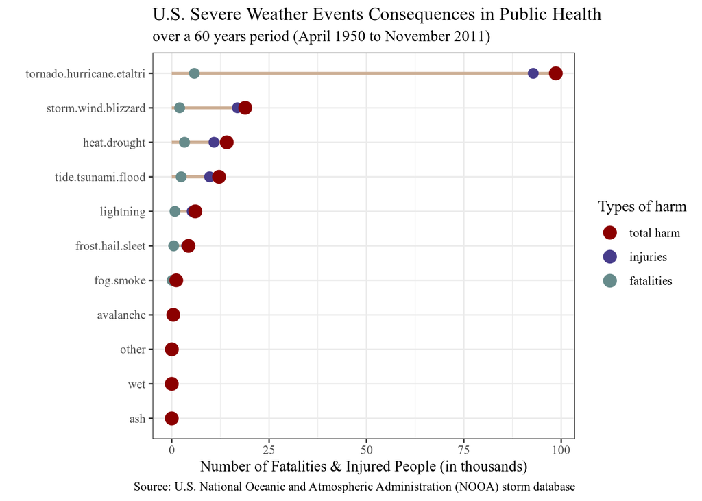

```r
human.damage.plot
```

Let’s remeber how that group of events is composed and check the precise numbers:

```r
library(dplyr)

## Events that belong to the "tornado.hurricane.etaltri" group.
sort(unique(storm_tidy$event[which(storm_tidy$event.group == "tornado.hurricane.etaltri")]))
 [1] cold air funnel                cold air funnels
 [3] cold air tornado               dust devel
 [5] dust devil                     dust devil waterspout
 [7] funnel                         funnel cloud
 [9] funnel cloud.                  funnel cloud/hail
[11] funnel clouds                  funnels
[13] gustnado                       gustnado and
[15] hurricane                      hurricane edouard
[17] hurricane emily                hurricane erin
[19] hurricane felix                hurricane gordon
[21] hurricane opal                 hurricane opal/high winds
[23] hurricane-generated swells     hurricane/typhoon
[25] landspout                      large wall cloud
[27] remnants of floyd              rotating wall cloud
[29] thunderstorm winds funnel clou thunderstorm winds/funnel clou
[31] tornado                        tornado debris
[33] tornado f0                     tornado f1
[35] tornado f2                     tornado f3
[37] tornado/waterspout             tornadoes
[39] tornadoes, tstm wind, hail     tornados
[41] torndao                        typhoon
[43] wall cloud                     wall cloud/funnel cloud
[45] water spout                    waterspout
[47] waterspout funnel cloud        waterspout tornado
[49] waterspout-                    waterspout-tornado
[51] waterspout/                    waterspout/ tornado
[53] waterspout/tornado             waterspouts
[55] wayterspout
815 Levels: abnormal warmth abnormally dry ... wnd

## Summaries.
storm_tidy %>% group_by(event.group) %>%
        summarize(human.damage = sum(fatalities + injuries),
                  fatalities = sum(fatalities),
                  injuries = sum(injuries)) %>%
        arrange(desc(human.damage))
# A tibble: 11 × 4
   event.group               human.damage fatalities injuries
   <fct>                            <dbl>      <dbl>    <dbl>
 1 tornado.hurricane.etaltri        98616       5801    92815
 2 storm.wind.blizzard              18870       2031    16839
 3 heat.drought                     14124       3269    10855
 4 tide.tsunami.flood               12138       2420     9718
 5 lightning                         6049        817     5232
 6 frost.hail.sleet                  4302        492     3810
 7 fog.smoke                         1158         81     1077
 8 avalanche                          396        225      171
 9 other                               20          9       11
10 ash                                  0          0        0
11 wet                                  0          0        0
```

> **Another fact that stands out is that, among the groups that follows after the first, the `heat.drought` group of events is more harmful in terms of** *fatalities*.

```r
## Events that belong to the "heat.drought" group.
sort(unique(storm_tidy$event[which(storm_tidy$event.group == "heat.drought")]))
 [1] abnormal warmth            abnormally dry
 [3] below normal precipitation brush fire
 [5] brush fires                driest month
 [7] drought                    drought/excessive heat
 [9] dry                        dry conditions
[11] dry hot weather            dry pattern
[13] dry spell                  dry weather
[15] dryness                    excessive
[17] excessive heat             excessive heat/drought
[19] excessively dry            extreme heat
[21] forest fires               grass fires
[23] heat                       heat drought
[25] heat wave                  heat wave drought
[27] heat waves                 heat/drought
[29] high temperature record    hot and dry
[31] hot pattern                hot spell
[33] hot weather                hot/dry pattern
[35] hyperthermia/exposure      mild and dry pattern
[37] mild pattern               mild/dry pattern
[39] prolong warmth             record dry month
[41] record dryness             record heat
[43] record heat wave           record high
[45] record high temperature    record high temperatures
[47] record temperature         record temperatures
[49] record warm                record warm temps.
[51] record warmth              record/excessive heat
[53] snow drought               temperature record
[55] unseasonably dry           unseasonably hot
[57] unseasonably warm          unseasonably warm & wet
[59] unseasonably warm and dry  unseasonably warm year
[61] unseasonably warm/wet      unusual warmth
[63] unusual/record warmth      unusually warm
[65] very dry                   very warm
[67] warm dry conditions        warm weather
[69] wild fires                 wild/forest fire
[71] wild/forest fires          wildfire
[73] wildfires
815 Levels: abnormal warmth abnormally dry ... wnd
```

> **Let’s finally notice that there are no harmful consequences registered in the `ash` and `wet` groups.**

```r
## Events that belong to the "ash" group.
sort(unique(storm_tidy$event[which(storm_tidy$event.group == "ash")]))
[1] vog                volcanic ash       volcanic ash plume volcanic ashfall
[5] volcanic eruption
815 Levels: abnormal warmth abnormally dry ... wnd
```

## 3.2 Economic consequences of severe weather events in the U.S.

We’ll approach the **second question** using the same strategy as before, but focusing on the variables that measure the economic consequences (`property.damage` and `crop.damage`).

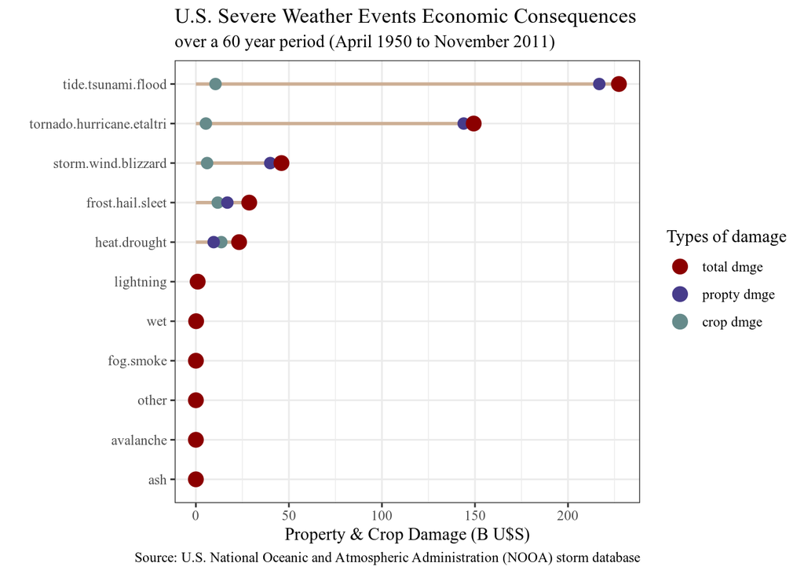

```r
library(dplyr)
library(ggplot2)

storm_tidy %>%
        ## Grouping by types of events.
        group_by(event.group) %>%
        ## Summarizing.
        summarize(economic.damage = sum(property.damage, crop.damage),
                  crop.damage = sum(crop.damage),
                  property.damage = sum(property.damage)) %>%
        ## Plotting.
        ggplot(aes(x = reorder(event.group, economic.damage),
                   y = economic.damage/10^9)) +
            geom_linerange(aes(ymin = 0,
                               ymax = economic.damage/10^9),
                           position = position_dodge(width = 0.2),
                           size = 1,
                           colour = "peachpuff3") +
            geom_point(aes(y = crop.damage/10^9, color = "paleturquoise4"),
                       size = 3) +
            geom_point(aes(y = property.damage/10^9, color = "slateblue4"),
                       size = 3) +
            geom_point(aes(color = "darkred"),
                       size = 4) +
            scale_color_identity(name = "Types of damage",
                                 ## force ggplot to recognize color names when they are inside aes()
                                 guide = "legend",
                                 ## order of the legends
                                 breaks = c("darkred", "slateblue4", "paleturquoise4" ),
                                 ## name of the legends
                                 labels = c("total dmge", "propty dmge", "crop dmge")) +
            labs(title = "U.S. Severe Weather Events Economic Consequences",
                 subtitle = "over a 60 year period (April 1950 to November 2011)",
                 caption = "Source: U.S. National Oceanic and Atmospheric Administration (NOOA) storm database",
                 x = "",
                 y = "Property & Crop Damage (B U$S)") +
            theme_bw(base_family = "Times New Roman", base_size = 11) +
            coord_flip()
```

Let’s see this more precisely:

```r
library(dplyr)

## Events that belong to the "tide.tsunami.flood" group.
sort(unique(storm_tidy$event[which(storm_tidy$event.group == "tide.tsunami.flood")]))
  [1] astronomical high tide         astronomical low tide
  [3] beach erosin                   beach erosion
  [5] beach erosion/coastal flood    beach flood
  [7] blow-out tide                  blow-out tides
  [9] breakup flooding               coastal erosion
 [11] coastal flood                  coastal flooding
 [13] coastal flooding/erosion       coastal surge
 [15] coastal/tidal flood            coastalflood
 [17] cstl flooding/erosion          dam break
 [19] dam failure                    erosion/cstl flood
 [21] flash flood                    flash flood from ice jams
 [23] flash flood landslides         flash flood/
 [25] flash flood/ flood             flash flood/ street
 [27] flash flood/flood              flash flood/landslide
 [29] flash flooding                 flash flooding/flood
 [31] flash floods                   flash floooding
 [33] flood                          flood flash
 [35] flood flood/flash              flood watch/
 [37] flood/flash                    flood/flash flood
 [39] flood/flash flooding           flood/flash/flood
 [41] flood/flashflood               flood/river flood
 [43] flooding                       floods
 [45] hail flooding                  hazardous surf
 [47] heavy rain/high surf           heavy seas
 [49] heavy surf                     heavy surf and wind
 [51] heavy surf coastal flooding    heavy surf/high surf
 [53] heavy swells                   high seas
 [55] high surf                      high surf advisories
 [57] high surf advisory             high swells
 [59] high tides                     high water
 [61] high waves                     high wind and high tides
 [63] high wind and seas             high wind/seas
 [65] highway flooding               ice jam
 [67] ice jam flood (minor           ice jam flooding
 [69] lake flood                     lakeshore flood
 [71] landslide                      landslide/urban flood
 [73] landslides                     landslump
 [75] local flash flood              local flood
 [77] major flood                    minor flood
 [79] minor flooding                 mud slide
 [81] mud slides                     mud slides urban flooding
 [83] mud/rock slide                 mudslide
 [85] mudslide/landslide             mudslides
 [87] rapidly rising water           rip current
 [89] rip currents                   rip currents heavy surf
 [91] rip currents/heavy surf        river and stream flood
 [93] river flood                    river flooding
 [95] rock slide                     rogue wave
 [97] rough seas                     rough surf
 [99] rural flood                    seiche
[101] small stream                   small stream and
[103] small stream and urban flood   small stream and urban floodin
[105] small stream flood             small stream flooding
[107] small stream urban flood       small stream/urban flood
[109] sml stream fld                 snowmelt flooding
[111] storm surge                    storm surge/tide
[113] stream flooding                street flood
[115] street flooding                tidal flood
[117] tidal flooding                 tsunami
[119] urban and small                urban and small stream
[121] urban and small stream flood   urban and small stream floodin
[123] urban flood                    urban flood landslide
[125] urban flooding                 urban floods
[127] urban small                    urban small stream flood
[129] urban/small                    urban/small flooding
[131] urban/small stream             urban/small stream flood
[133] urban/small stream flooding    urban/small strm fldg
[135] urban/sml stream fld           urban/sml stream fldg
[137] urban/street flooding
815 Levels: abnormal warmth abnormally dry ... wnd

## Summaries.
storm_tidy %>% group_by(event.group) %>%
        summarize(economic.damage = sum(property.damage + crop.damage),
                  property.damage = sum(property.damage),
                  crop.damage = sum(crop.damage)) %>%
        arrange(desc(economic.damage))
# A tibble: 11 × 4
   event.group               economic.damage property.damage crop.damage
   <fct>                               <dbl>           <dbl>       <dbl>
 1 tide.tsunami.flood          227358049782.   216813547282. 10544502500
 2 tornado.hurricane.etaltri   149318149328.   143938851916.  5379297411
 3 storm.wind.blizzard          46006780815.    39967323727.  6039457088
 4 frost.hail.sleet             28675198306.    16927992763. 11747205543
 5 heat.drought                 23227759540      9563060250  13664699290
 6 lightning                      985028830.      940737930.    44290900
 7 wet                            142000000               0    142000000
 8 fog.smoke                       25111500        25111500            0
 9 other                           10499500          155500     10344000
10 avalanche                        8721800         8721800            0
11 ash                               500000          500000            0
```

We can also notice that:

> **The most part of the total economic consequences produced by the three first groups (`tide.tsunami.flood`, `tornado.hurricane.etaltri` and `storm.wind.blizzard`), are property damage.**

> **Groups in fourth and fifth place (`frost.hail.sleet` and `heat.drought`) produce less damage in total economic terms, but have the greatest consequences in terms of crop damage.**

Having just remembered how `heat.drought` group was composed, let’s recall `frost.hail.sleet` group:

```r
## Events that belong to the "frost.hail.sleet" group.
sort(unique(storm_tidy$event[which(storm_tidy$event.group == "frost.hail.sleet")]))
  [1] accumulated snowfall          agricultural freeze
  [3] black ice                     blowing snow
  [5] cold                          cold and frost
  [7] cold and snow                 cold and wet conditions
  [9] cold temperature              cold temperatures
 [11] cold wave                     cold weather
 [13] cool and wet                  cool spell
 [15] damaging freeze               deep hail
 [17] drifting snow                 early freeze
 [19] early frost                   early snow
 [21] early snowfall                excessive cold
 [23] excessive snow                extended cold
 [25] extreme cold                  extreme/record cold
 [27] falling snow/ice              first frost
 [29] first snow                    freeze
 [31] freezing drizzle              freezing drizzle and freezing
 [33] freezing spray                frost
 [35] frost/freeze                  frost\\freeze
 [37] glaze                         glaze ice
 [39] hail                          hail 0.75
 [41] hail 0.88                     hail 075
 [43] hail 088                      hail 1.00
 [45] hail 1.75                     hail 1.75)
 [47] hail 100                      hail 125
 [49] hail 150                      hail 175
 [51] hail 200                      hail 225
 [53] hail 275                      hail 450
 [55] hail 75                       hail 80
 [57] hail 88                       hail aloft
 [59] hail damage                   hail(0.75)
 [61] hail/icy roads                hard freeze
 [63] heavy lake snow               heavy mix
 [65] heavy snow                    heavy snow & ice
 [67] heavy snow and                heavy snow and ice
 [69] heavy snow andblowing snow    heavy snow squalls
 [71] heavy snow-squalls            heavy snow/blowing snow
 [73] heavy snow/high               heavy snow/ice
 [75] heavy snow/sleet              heavy snow/squalls
 [77] heavy snowpack                heavy wet snow
 [79] hypothermia                   hypothermia/exposure
 [81] ice                           ice and snow
 [83] ice floes                     ice on road
 [85] ice pellets                   ice roads
 [87] ice/snow                      icy roads
 [89] lack of snow                  lake effect snow
 [91] lake-effect snow              late freeze
 [93] late season hail              late season snow
 [95] late season snowfall          late snow
 [97] late-season snowfall          light snow
 [99] light snow and sleet          light snow/flurries
[101] light snow/freezing precip    light snowfall
[103] low temperature               low temperature record
[105] marine hail                   moderate snow
[107] moderate snowfall             monthly snowfall
[109] monthly temperature           mountain snows
[111] near record snow              non severe hail
[113] patchy ice                    prolong cold
[115] prolong cold/snow             record cold
[117] record cold/frost             record cool
[119] record low                    record may snow
[121] record snow                   record snow/cold
[123] record snowfall               record winter snow
[125] seasonal snowfall             severe cold
[127] sleet                         sleet/snow
[129] small hail                    snow
[131] snow accumulation             snow advisory
[133] snow and cold                 snow and heavy snow
[135] snow and ice                  snow and sleet
[137] snow sleet                    snow squall
[139] snow squalls                  snow/ bitter cold
[141] snow/ ice                     snow/blowing snow
[143] snow/cold                     snow/heavy snow
[145] snow/ice                      snow/sleet
[147] snow\\cold                    snowfall record
[149] thundersnow                   unseasonable cold
[151] unseasonably cold             unseasonably cool
[153] unseasonably cool & wet       unseasonal low temp
[155] unusually cold                unusually late snow
[157] wet snow                      winter mix
[159] winter weather                winter weather mix
[161] winter weather/mix            wintery mix
[163] wintry mix
815 Levels: abnormal warmth abnormally dry ... wnd
```

## 3.3 Looking by decades.

We finally want to get a sense of the data when we look at it divided by decades.

Let’s take the total economic consequences (property + crop damage) of the events, as the sample measure to carrie out this last inspection.

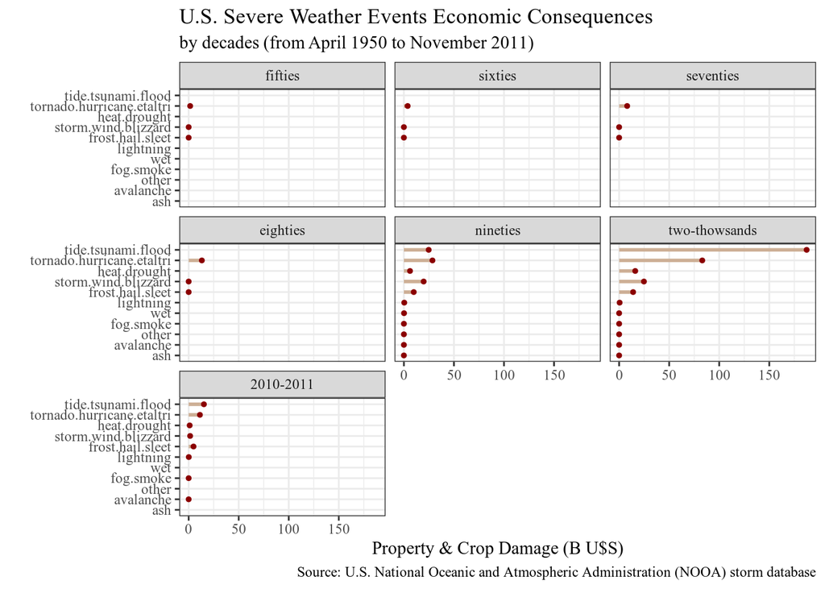

```r
library(dplyr)
library(ggplot2)

## Creating the labels that will be used in the faceted graphic.
decade_levels <- levels(cut.Date(storm_tidy$date, breaks = "10 year"))

storm_tidy %>%
        ## Factorizing "date" variable by decades.
        mutate(decade = cut.Date(date, breaks = "10 year"),
               decade = factor(decade, levels = decade_levels,
                               labels = c("fifties", "sixties",
                               "seventies", "eighties", "nineties",
                               "two-thowsands", "2010-2011") )) %>%
        ## Grouping by classes of events and decades.
        group_by(event.group, decade) %>%
        ## Summarizing.
        summarize(economic.damage = sum(property.damage, crop.damage)) %>%
        ## Plotting.
        ggplot(aes(x = reorder(event.group, economic.damage),
                   y = economic.damage/10^9)) +
            facet_wrap(. ~ decade) +
            geom_linerange(aes(ymin = 0,
                               ymax = economic.damage/10^9),
                           position = position_dodge(width = 0.2),
                           size = 1,
                           colour = "peachpuff3") +
            geom_point(color = "darkred",
                       size = 1) +
            labs(title = "U.S. Severe Weather Events Economic Consequences",
                 subtitle = "by decades (from April 1950 to November 2011)",
                 caption = "Source: U.S. National Oceanic and Atmospheric Administration (NOOA) storm database",
                 x = "",
                 y = "Property & Crop Damage (B U$S)") +
            theme_bw(base_family = "Times New Roman", base_size = 11) +
            coord_flip()
```

The figure above allows us to realize that:

> **From the 50s to the 80s, there are fewer data recorded.**

> **In the 90s the `tornado.hurricane.etaltri` has greater economic consequences than `tide.tsunami.flood` group. The situation then changes in the 2000s where the `tide.tsunami.flood` group happens to lead the ranking with a big difference.**

> **A further analysis would be necessary to find out why this latest change in trend occured, if it’s due for instance to a change in the methodology or amount of data registered in the database, or to an increase in the number or severity of the phenomena belonging to the `tide.tsunami.flood` group from one decade to the other.**

# 4 Session info.

Below is a summary of the software and hardware used to make this report.

```r
sessionInfo()
R version 3.6.3 (2020-02-29)
Platform: x86_64-pc-linux-gnu (64-bit)
Running under: Ubuntu 18.04.6 LTS

Matrix products: default
BLAS:   /usr/lib/x86_64-linux-gnu/blas/libblas.so.3.7.1
LAPACK: /usr/lib/x86_64-linux-gnu/lapack/liblapack.so.3.7.1

locale:
 [1] LC_CTYPE=es_AR.UTF-8          LC_NUMERIC=C
 [3] LC_TIME=es_AR.UTF-8           LC_COLLATE=es_AR.UTF-8
 [5] LC_MONETARY=es_AR.UTF-8       LC_MESSAGES=es_AR.UTF-8
 [7] LC_PAPER=es_AR.UTF-8          LC_NAME=es_AR.UTF-8
 [9] LC_ADDRESS=es_AR.UTF-8        LC_TELEPHONE=es_AR.UTF-8
[11] LC_MEASUREMENT=es_AR.UTF-8    LC_IDENTIFICATION=es_AR.UTF-8

attached base packages:
[1] stats     graphics  grDevices utils     datasets  methods   base

other attached packages:
 [1] R.utils_2.10.1     R.oo_1.24.0        R.methodsS3_1.8.1  impute_1.60.0
 [5] RColorBrewer_1.1-2 maps_3.3.0         stringr_1.4.0      lubridate_1.9.2
 [9] quantmod_0.4.20    TTR_0.24.2         xts_0.12.1         zoo_1.8-9
[13] readr_2.0.1        tidyr_1.2.0        dplyr_1.0.8        reshape2_1.4.4
[17] Hmisc_4.4-0        ggplot2_3.3.5      Formula_1.2-3      survival_3.4-0
[21] lattice_0.20-45    jpeg_0.1-8.1       gitignore_0.1.3    rhdf5_2.30.1
[25] httr_1.4.2         httpuv_1.6.3       sqldf_0.4-11       RSQLite_2.2.0
[29] gsubfn_0.7         proto_1.0.0        DBI_1.1.1          data.table_1.14.0
[33] jsonlite_1.7.2     XML_3.99-0.3       xlsx_0.6.3         plyr_1.8.6

loaded via a namespace (and not attached):
 [1] colorspace_2.0-3    ellipsis_0.3.2      htmlTable_2.0.1
 [4] base64enc_0.1-3     rstudioapi_0.13     farver_2.1.0
 [7] bit64_4.0.5         fansi_1.0.2         splines_3.6.3
[10] knitr_1.41          rJava_0.9-13        cluster_2.1.4
[13] png_0.1-7           clipr_0.7.1         compiler_3.6.3
[16] backports_1.4.1     assertthat_0.2.1    Matrix_1.5-1
[19] fastmap_1.1.0       cli_3.6.0           later_1.3.0
[22] formatR_1.14        acepack_1.4.1       htmltools_0.5.2
[25] tools_3.6.3         gtable_0.3.0        glue_1.6.2
[28] Rcpp_1.0.7          jquerylib_0.1.4     vctrs_0.5.2
[31] nlme_3.1-162        xfun_0.36           xlsxjars_0.6.1
[34] timechange_0.2.0    lifecycle_1.0.3     scales_1.1.1
[37] vroom_1.5.5         hms_1.1.0           promises_1.2.0.1
[40] parallel_3.6.3      yaml_2.2.1          curl_4.3.2
[43] memoise_1.1.0       gridExtra_2.3       sass_0.4.0
[46] rpart_4.1.19        latticeExtra_0.6-29 stringi_1.7.6
[49] highr_0.9           checkmate_2.0.0     chron_2.3-55
[52] rlang_1.0.6         pkgconfig_2.0.3     evaluate_0.19
[55] purrr_0.3.4         Rhdf5lib_1.8.0      htmlwidgets_1.5.4
[58] labeling_0.4.2      bit_4.0.4           tidyselect_1.2.0
[61] magrittr_2.0.2      R6_2.5.1            generics_0.1.2
[64] pillar_1.7.0        foreign_0.8-76      withr_2.5.0
[67] mgcv_1.8-41         nnet_7.3-18         tibble_3.1.8
[70] crayon_1.5.0        KernSmooth_2.23-20  utf8_1.2.2
[73] tzdb_0.3.0          rmarkdown_2.11      grid_3.6.3
[76] blob_1.2.2          digest_0.6.29       openssl_2.0.5
[79] munsell_0.5.0       viridisLite_0.4.0   bslib_0.3.0
[82] tcltk_3.6.3         askpass_1.1
```